# challenge_Piervincenzo_Ventrella

Notebook by Piervincenzo Ventrella (piervincenzov@gmail.com).

#### Structure of the notebook:

##### 1) Exploratory Data Analysis:

--- 1.1 Target Variable analysis  
--- 1.2 Spotting outliers  
--- 1.3 Dealing with missing values  
------- 1.3.1 Dealing with variable 'description  
--- 1.4 Recap  
--- 1.5 Analyzing how imput variables behave with respect to TARGET - Feature Engineering  
--- 1.6 Correlation Analysis  
--- 1.7 OHE of the CATEGORICAL variables  
--- 1.8 Recap

##### 2) Regression Models:

--- 2.1 Introduction  
--- 2.2 Normalization  
--- 2.3 Crossvalidation  
--- 2.4 Select best model  
--- 2.5 Future work

```python
#import some libraries
import pandas as pd
import numpy as np
import matplotlib.pyplot as plt
import seaborn as sns
%matplotlib inline

sns.set_style("whitegrid")
plt.style.use("fivethirtyeight")
```

```python
#load dataset
dataset = pd.read_csv('./berlin.csv')
dataset.head()
```

|  | id | property_type_id | market_type | price_m2 | area | building_year | posted_at | ended_at | num_days | zip_code | ... | floor | num_rooms | living_space | num_bedrooms | num_bathrooms | num_floors | apartment_type | condition | interior_quality | description |
| --- | --- | --- | --- | --- | --- | --- | --- | --- | --- | --- | --- | --- | --- | --- | --- | --- | --- | --- | --- | --- | --- |
| 0 | 2232353 | 3.0 | rent | 11.197399 | 55.37 | 1929.0 | 2018-03-15 | 2018-03-19 | 3.0 | 13351.0 | ... | 0.0 | 2.0 | 55.37 | 1.0 | 1.0 | 3.0 | Erdgeschosswohnung | Saniert | Normale Qualität | Es handelt sich um eine gepflegte Wohnanlage w... |
| 1 | 2232370 | 3.0 | rent | 9.959539 | 32.13 | 1900.0 | 2018-03-19 | 2018-03-21 | 1.0 | 13353.0 | ... | 0.0 | 1.0 | 32.13 | NaN | NaN | 4.0 | Erdgeschosswohnung | NaN | NaN | Schöne renovierte Studentenwohnung sucht Miete... |
| 2 | 2232380 | 3.0 | rent | 9.661290 | 62.00 | 1963.0 | 2018-03-19 | 2018-06-04 | 76.0 | 12357.0 | ... | 2.0 | 2.0 | 62.00 | NaN | 1.0 | NaN | Etagenwohnung | Modernisiert | Normale Qualität | Die Wohnanlage liegt im Süden Berlins im attra... |
| 3 | 2232383 | 3.0 | rent | 12.488095 | 84.00 | 1900.0 | 2018-03-19 | 2018-04-19 | 30.0 | 10961.0 | ... | 4.0 | 3.0 | 84.00 | NaN | 1.0 | NaN | Etagenwohnung | Modernisiert | Normale Qualität | Die hier angebotene, frisch modernisierte 3-Zi... |
| 4 | 2232388 | 3.0 | rent | 9.500000 | 150.00 | 1912.0 | 2018-03-19 | 2018-04-05 | 16.0 | 13465.0 | ... | NaN | 5.0 | 150.00 | NaN | NaN | NaN | NaN | NaN | NaN | In einer sehr angenehmen, ruhigen und bevorzug... |

5 rows × 27 columns

```python
dataset.shape
```

```
(36000, 27)
```

The dataset is composed by 36k instances and contains 27 variables.  
Let's take a quick look:

```python
dataset.describe().T
```

|  | count | mean | std | min | 25% | 50% | 75% | max |
| --- | --- | --- | --- | --- | --- | --- | --- | --- |
| property_type_id | 35986.0 | 3.000000e+00 | 0.000000 | 3.000000e+00 | 3.000000e+00 | 3.000000e+00 | 3.000000e+00 | 3.000000e+00 |
| price_m2 | 35986.0 | 1.156293e+01 | 3.338827 | 2.574020e+00 | 9.228011e+00 | 1.100000e+01 | 1.341463e+01 | 4.000000e+01 |
| area | 35986.0 | 7.362594e+01 | 34.360641 | 2.000000e+01 | 5.223000e+01 | 6.600000e+01 | 8.634750e+01 | 5.200000e+02 |
| building_year | 29525.0 | 1.951297e+03 | 43.017354 | 1.667000e+03 | 1.909000e+03 | 1.955000e+03 | 1.993000e+03 | 2.019000e+03 |
| num_days | 35470.0 | 2.993905e+01 | 37.950605 | -1.810000e+02 | 5.000000e+00 | 1.500000e+01 | 4.100000e+01 | 3.850000e+02 |
| zip_code | 35986.0 | 1.201676e+04 | 1308.749323 | 1.011500e+04 | 1.058700e+04 | 1.224700e+04 | 1.318700e+04 | 1.419900e+04 |
| city_id | 35986.0 | 1.100000e+07 | 0.000000 | 1.100000e+07 | 1.100000e+07 | 1.100000e+07 | 1.100000e+07 | 1.100000e+07 |
| latitude | 35760.0 | 5.250226e+01 | 0.557399 | 0.000000e+00 | 5.247305e+01 | 5.251130e+01 | 5.254285e+01 | 5.264656e+01 |
| longitude | 35760.0 | 1.339305e+01 | 0.174641 | 0.000000e+00 | 1.332685e+01 | 1.339468e+01 | 1.345436e+01 | 1.373370e+01 |
| floor | 31116.0 | 2.607244e+00 | 5.391362 | -1.000000e+00 | 1.000000e+00 | 2.000000e+00 | 4.000000e+00 | 8.720000e+02 |
| num_rooms | 35883.0 | 2.421769e+00 | 1.438569 | 1.000000e+00 | 2.000000e+00 | 2.000000e+00 | 3.000000e+00 | 1.700000e+02 |
| living_space | 34610.0 | 7.408145e+01 | 34.644700 | 0.000000e+00 | 5.260000e+01 | 6.624000e+01 | 8.700000e+01 | 5.200000e+02 |
| num_bedrooms | 15069.0 | 1.607074e+00 | 0.835505 | 0.000000e+00 | 1.000000e+00 | 1.000000e+00 | 2.000000e+00 | 1.100000e+01 |
| num_bathrooms | 23255.0 | 1.134982e+00 | 0.370686 | 0.000000e+00 | 1.000000e+00 | 1.000000e+00 | 1.000000e+00 | 1.100000e+01 |
| num_floors | 21147.0 | 4.612049e+00 | 2.516016 | 0.000000e+00 | 4.000000e+00 | 4.000000e+00 | 5.000000e+00 | 1.570000e+02 |

### Numerical Features

price_m2: apartment price square meter [TARGET VARIABLE TO PREDICT]  
area: apartment area  
building_year: year when the building was build  
posted_at: date the apartment was listed in the web page for rent  
ended_at: date the apartment was removed from the web page  
num_days: days between posted_at and ended_at  
street_number: apartment street number  
latitude: apartment latitude  
longitude: apartment longitude  
floor: apartment floor  
num_rooms: all rooms of the apartment (bedrooms, salon...)  
living_space: apartment area excluding exterior zones  
num_bedrooms: apartment number of bedrooms  
num_bathrooms: apartment number of bathrooms  
num_floors: building number of floors

### Categorical Features

id: Unique identifier of the apartment  
property_type_id: always '3' (means apartment)  
market_type: always 'rent'  
zip_code: zip code  
city_id: id of the the city (always 11000000 -> Berlin)  
district_id: subdivision of zip_codes  
zone_id: subdivision of district_id  
street: apartment street  
apartment_type: apartment classification (in german)  
condition: apartment condition (in german)  
interior_quality: apartment quality (in german)  
description: apartment description (in german)

##### The first thing we do, before analyzing the data, is to split the original dataset into training and test. We should never get in touch with the test set!

```python
FEATURES = []
for col in dataset.columns:
    if col != "price_m2":
        FEATURES.append(col)
TARGET = "price_m2"
```

```python
from sklearn.model_selection import train_test_split
#split into train and test
train, test = train_test_split(dataset, test_size=0.3, random_state=101)
print(train.shape)
print(test.shape)
```

```
(25200, 27)
(10800, 27)
```

# 1 Exploratory Data Analysis (EDA)

### 1.1 Target Variable analysis

Let's check first the distribution of the TARGET variable on the training set:

```python
train[TARGET].describe()
```

```
count    25190.000000
mean        11.572382
std          3.351938
min          2.574020
25%          9.224603
50%         11.000000
75%         13.455378
max         37.426682
Name: price_m2, dtype: float64
```

Note: there are 10 examples where the TARGET variable is Nan.  
We decide to eliminate those examples because:

- they are just 10 over 25190 (<< 1%);
- it does make really sense to impute the TARGET, we should rather apply this process on the input variables.

```python
#eliminate examples where target variable is nan or  target variable is <= 0
train = train[train.price_m2 > 0]
train.shape
```

```
(25190, 27)
```

##### Does the TARGET variable follow a normal distribution?

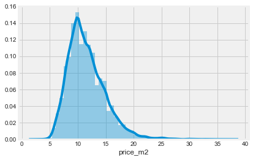

```python
#plot target variable distibution
sns.distplot(train[TARGET])
```

```python
print("Kurtosisis index: " + str(round(train[TARGET].kurtosis(),2)))
print("Skew index: " + str(round(train[TARGET].skew(),2)))
```

```
Kurtosisis index: 2.73
Skew index: 1.14
```

##### Skewness interpretation

If the peak of the distribution is on the left of the average value (as in this scenario), portraying a positive skewness in the distribution, it means that many houses are being sold for less than the average value. This could be for many reasons and we should investigate that. If the peak of the distributed data is on the right of the average value, that means a negative skew. This means that the houses are being sold for more than the average value.

##### Kurtosis interpretation

Kurtosis is about the tails of the distribution. It is used to describe the extreme values in one versus the other tail. It is actually the measure of outliers present in the distribution. High kurtosis in a data set is an indicator that data has heavy tails or outliers. If there is a high kurtosis (as in this case), then, we need to investigate why do we have so many outliers. It indicates a lot of things, maybe wrong data entry or other things.

The 2 values indicate that the TARGET variable is pretty skewed. A common procedure to deal with that and reduce this effect is to **apply a log scale** that usually allows to reach better performance in regression tasks.

```python
#create new column applying log scale to the TARGET variable
import math
train['log_price_m2'] = train.apply(lambda x : math.log10(x[TARGET]),axis=1)
```

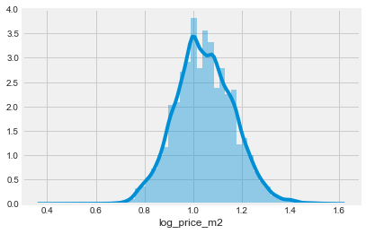

```python
#check new scaled distribution
sns.distplot(train['log_price_m2'])
```

```python
print("Kurtosisis index: " + str(round(train['log_price_m2'].kurtosis(),2)))
print("Skew index: " + str(round(train['log_price_m2'].skew(),2)))
```

```
Kurtosisis index: 0.16
Skew index: 0.15
```

How we can notice, the values of skewness are much smaller now and the scaled target variable follows a Gaussian distibution. Therefore, from now on, we will consider this as TARGET variable and when needed we will come back to the original target variable.

```python
LOG_TARGET = 'log_price_m2'
```

### 1.2 Spotting outliers:

Let's analyze better the numerical variables and see if there are outliers:

```python
NUM_FEATURES = [ 'area', 'building_year', 'num_days',
                 'floor', 'num_rooms', 'living_space', 'num_bedrooms',
                'num_bathrooms', 'num_floors']
```

Let's check for example the variable 'num_rooms':

```python
print('num_rooms:')
print(train['num_rooms'].describe())
print()
num_rooms_quantlile95 = train['num_rooms'].quantile(.95)
print('95% quantile is: ' + str(num_rooms_quantlile95))
```

```
num_rooms:
count    25123.000000
mean         2.419609
std          1.539534
min          1.000000
25%          2.000000
50%          2.000000
75%          3.000000
max        170.000000
Name: num_rooms, dtype: float64

95% quantile is: 4.0
```

**Note:** the variable 'num_rooms' contains some outliers (there is an instance for which the total number of rooms is 170 when the 95% quantile is 4). We replace them with the 95% quantile.

```python
#replace the values of 'num_rooms' that are above the 95% quantile with th quantile itself.
train['num_rooms'] = train.apply(lambda x : (num_rooms_quantlile95 if x['num_rooms'] > num_rooms_quantlile95   else  x['num_rooms']),axis=1)
train['num_rooms'].describe()
```

```
count    25123.000000
mean         2.365097
std          0.883962
min          1.000000
25%          2.000000
50%          2.000000
75%          3.000000
max          4.000000
Name: num_rooms, dtype: float64
```

That's better now. **Note:** instead of replacing those values with the 95% quantile, another common procedure is to consider them as missing values but for now we go with the first option.  
Let's apply the same replacement procedure to the other NUMERICAL VARIABLES:

```python
for var in NUM_FEATURES:
    quantlile95 = train[var].quantile(.95)
    train[var] = train.apply(lambda x : (quantlile95 if x[var] > quantlile95   else  x[var]),axis=1)
```

Now, at least for the NUMERICAL FEATURES/VARIABLES, we should have removed outliers. Let's deal with the missing values now.

### 1.3 Dealing with missing values

The first thing that should be done when dealing with missing value is to try understanding why data are missing and which kind of missing values we are dealing with. In particular, the types of missing values could be:

- missing completely at random (MCAR);
- missing at random (MAR);
- not missing at random (NMAR);  
  In the last scenario, the first thing that should be done is to come back to the source of data and investigating more on why these data are missing (i.e. consider a survey about Incomes, people with high Incomes could be less prone of communicating the Information and therefore Imputing the missing value with mean or median could be inappropriate). Unfortunately I don't have further information on how the data is been collected so I will consider the missing values as MCAR/CAR.

Apart from that, you could deal with missing values in different ways:

- you could apply a list-wise deletion to all the instances that have a missing value, but this could reduce too much the size of the dataset, so It Is worth only for small percentages of missing values. Eventually you could delete only the instances that present a percentage of missing values (over the different attributes of the Instance) that Is higher than a threshold (I.e. 50%).
- you could decide to delete an entire column/attribute/feature If the percentage of missing values for that attribute Is higher than a threshold;
- finally, you could decide to Impute the missing values using for example the mean or the median (that are the most common Imputation techniques because they are quick to Implement and work well). You should preferer the median over the mean when there are several outliers (mean is sensitive to outliers) or first remove the outliers and consider them as missing values. - there are also more sophisticated Imputation techniques: for example you could use a regression model to Impute the missing variables or you could replace It with a random chosen value from an Instance from the population that Is similar to the Instance on which we are performing Imputation (this technique is called hot deck imputation). The ones mentioned above are some example of 'single Imputation' techniques but there also exist 'multiple imputation' techniques, a little bit more sophisticated, that allow to assign multiple possible values to the missing attribute and are less biased.

Some remarks:  
Imputation Is useful because the major part of the Machine Learning algorithms cannot deal with missing values but there are some other algorithms (i.e. Naïve Bayes) that can also deal with missing values.  
You could also keep track of which value Is been Imputed and which not and supplying this Information to the algorithms with a binary variable (Imputed/not Imputed).

#### Let's check the distribution of missing values

##### Numerical variables:

```python
NUM_FEATURES.extend(['latitude', 'longitude','num_days'])
```

```python
#check the count of each variable
count = train[NUM_FEATURES].describe().T['count']
count
```

```
area             25190.0
building_year    20695.0
num_days         24840.0
floor            21770.0
num_rooms        25123.0
living_space     24222.0
num_bedrooms     10514.0
num_bathrooms    16242.0
num_floors       14834.0
latitude         25031.0
longitude        25031.0
num_days         24840.0
Name: count, dtype: float64
```

```python
#converto into list for visualization purposes
count = count.values.tolist()
```

```python
#missing % and Kurtosis index for each NUMERICAL VARIABLE
missing_ratios = []
for i in range(len(NUM_FEATURES)):
    percentage = round((train.shape[0] - count[i])/train.shape[0] *100,2)
    print( NUM_FEATURES[i] + ': ' + str(percentage) + "%")
    print('kurtosis index: ' + str(round(train[NUM_FEATURES[i]].kurtosis(),2)))
    print('---')
    missing_ratios.append(percentage)
```

```
area: 0.0%
kurtosis index: -0.03
---
building_year: 17.84%
kurtosis index: -1.29
---
num_days: 1.39%
kurtosis index: 0.76
---
floor: 13.58%
kurtosis index: -0.67
---
num_rooms: 0.27%
kurtosis index: -0.66
---
living_space: 3.84%
kurtosis index: -0.06
---
num_bedrooms: 58.26%
kurtosis index: -0.6
---
num_bathrooms: 35.52%
kurtosis index: 2.88
---
num_floors: 41.11%
kurtosis index: 0.44
---
latitude: 0.63%
kurtosis index: 12253.9
---
longitude: 0.63%
kurtosis index: 4176.17
---
num_days: 1.39%
kurtosis index: 0.76
---
```

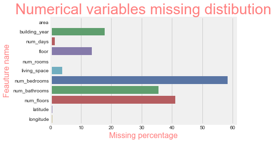

```python
#plot the missing value % for each NUMERICAL VARIABLE

# Create a bar graph
bar_plot = sns.barplot(x=missing_ratios,y=NUM_FEATURES, palette="deep")
# Set title of the bar graph
bar_plot.set_title("Numerical variables missing distibution", size=30, color="r", alpha=0.5)
# Set x-axis of the bar graph
bar_plot.set_xlabel("Missing percentage", size =16, color="r", alpha=0.5)
# Set y-axis of the bar graph
bar_plot.set_ylabel("Feauture name", size=16, color="r", alpha=0.5)

# Show the bar graph
plt.show()
```

**Note:** there are several variables with high percentage of missing ratio (i.e. num_bathrooms, num_bedrooms, num_floors). Before eventually impute them, do we know somenthing more about those attributes?

- num_bedrooms is the variable with the highest missing %. Rather than imputing it, we could try to compute it from the other 2 variables num_rooms and num_bathrooms (i.e. num_bedrooms = num_rooms - num_bathrooms?)

Let's check if the assumption **'num_rooms = num_bedrooms + num_bathrooms'** is true:

```python
train['num_bath_bed_rooms'] = train.apply(lambda x : (x['num_bathrooms'] + x['num_bedrooms']),axis=1)
```

If the assumption is true, the distribution of ('num_bath_bed_rooms' - 'num_rooms') should have mean and std really close to zero:

```python
room_difference = train.apply(lambda x : (x['num_bath_bed_rooms'] - x['num_rooms']),axis=1)
room_difference.describe()
```

```
count    10351.000000
mean         0.226452
std          0.595693
min         -4.000000
25%          0.000000
50%          0.000000
75%          1.000000
max          4.000000
dtype: float64
```

Unfortunately, the distribution does not have mean and std really close to zero.

if the assumpiton is true, we should obtain something really similar to and identity function (x=y) when we plot 'num_bath_bed_rooms' with respect to 'num_rooms':

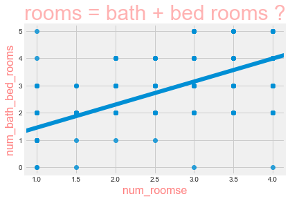

```python
# Create scatter/reg plot
regplot = sns.regplot(x=train['num_rooms'],y=train['num_bath_bed_rooms'])
# Set title
regplot.set_title("rooms = bath + bed rooms ?", size=30, color="r", alpha=0.3)
# Set x-axis
regplot.set_xlabel("num_roomse", size =16, color="r", alpha=0.5)
# Set y-axis
regplot.set_ylabel("num_bath_bed_rooms", size=16, color="r", alpha=0.5)

# Show the bar graph
plt.show()
```

Unfortunately the scatter plot does not show exaclty an identity function. We have to refuse the assumption and therefore we cannot use the equation 'num_rooms = num_bedrooms + num_bathrooms' in order to impute the missing values for those variables. Maybe we could take into account also the variable 'appartment_type' to have a better relationship, but for the sake of simplicity we treat those missing values as the ones of other variables and we normally impute them. Let's drop therefore the column 'num_bath_bed_rooms':

```python
print(train.shape)
train = train.drop(['num_bath_bed_rooms'], 1)
print(train.shape)
```

```
(25190, 29)
(25190, 28)
```

Now, how we impute the missing values for the numerical features? As discussed before, mean or median imputation, are simple but effective techniques. We choose to use the median (more robust to outliers) because, even if we previously replaced some examples that we considered as outliers, the distibution of the variables still shows an important Kurtosis index.

#### Imputation of missing values for numerical features

When imputing the missing values, we will keep track of which variable is been imputed. Therefore we add a column for each input feature in the dataset that will consist in a binary variable (1 if the variable is imputed, 0 otherwise).

```python
#create a column 'variableName_imputed' for each variable in NUM_FEATURES
print(train.shape)
for var in NUM_FEATURES:
    var_imputed = var + "_imputed"
    train[var_imputed] = pd.DataFrame(np.zeros((train.shape[0], 1)))
print(train.shape)
```

```
(25190, 28)
(25190, 39)
```

```python
for var in NUM_FEATURES:
    print(str(var) + ":")
    print("Count before imputing: " + str(train[var].count()))
    computed_median = train[var].median(skipna = True)
    #keep track of the variables that will be imputed
    var_imputed = var + "_imputed"
    train[var_imputed] = train.apply(lambda x : (1 if math.isnan(x[var])  else  0),axis=1)
    train[var] = train.apply(lambda x : (computed_median if math.isnan(x[var])  else  x[var]),axis=1)
    print("Count after imputing: " + str(train[var].count()))
    print()
```

```
area:
Count before imputing: 25190
Count after imputing: 25190

building_year:
Count before imputing: 20695
Count after imputing: 25190

num_days:
Count before imputing: 24840
Count after imputing: 25190

floor:
Count before imputing: 21770
Count after imputing: 25190

num_rooms:
Count before imputing: 25123
Count after imputing: 25190

living_space:
Count before imputing: 24222
Count after imputing: 25190

num_bedrooms:
Count before imputing: 10514
Count after imputing: 25190

num_bathrooms:
Count before imputing: 16242
Count after imputing: 25190

num_floors:
Count before imputing: 14834
Count after imputing: 25190

latitude:
Count before imputing: 25031
Count after imputing: 25190

longitude:
Count before imputing: 25031
Count after imputing: 25190

num_days:
Count before imputing: 25190
Count after imputing: 25190
```

All the numerical features have been imputed! Let's focus now on the other features listed below:

- id: Unique identifier of the apartment
- property_type_id: always '3' (means apartment)
- market_type: always 'rent'
- zip_code: zip code
- city_id: id of the the city (always 11000000 -> Berlin)
- district_id: subdivision of zip_codes
- zone_id: subdivision of district_id
- street: apartment street
- apartment_type: apartment classification (in german)
- condition: apartment condition (in german)
- interior_quality: apartment quality (in german)
- description: apartment description (in german)

Let's analyze the variable 'id':

```python
train['id'].describe()
```

```
count       25190
unique      25190
top       2538981
freq            1
Name: id, dtype: object
```

variable 'id' does not have missing values. This variable is not usefull for the training of regression algorithms but could be usefull later to identify the houses, therefore we leave it in the dataframe.  
Variables:

- property_type_id: always '3' (means apartment)
- market_type: always 'rent'
- city_id: id of the the city (always 11000000 -> Berlin)

are useless because they always have the same values. Therefore we eliminate them:

```python
print("train shape: " + str(train.shape))
train = train.drop(['property_type_id', 'market_type', 'city_id'], 1)
print("train shape: " + str(train.shape))
```

```
train shape: (25190, 39)
train shape: (25190, 36)
```

```python
CAT_FEATURES = ['zip_code','district_id', 'zone_id', 'street', 'apartment_type', 'condition', 'interior_quality', 'description']
```

```python
#Let's take a look to these variables, for which mean, std, etc do not have any meaning
summary = train[CAT_FEATURES].describe(include = 'all').T
summary = summary.drop(['mean', 'std', 'min', '25%', '50%', '75%', 'max'], 1)
summary
```

|  | count | unique | top | freq |
| --- | --- | --- | --- | --- |
| zip_code | 25190 | NaN | NaN | NaN |
| district_id | 25184 | 12 | 11000000_4_006 | 3484 |
| zone_id | 25184 | 94 | 11000000_5_009 | 1469 |
| street | 20386 | 5842 | Chausseestraße | 69 |
| apartment_type | 20983 | 10 | Etagenwohnung | 14545 |
| condition | 18774 | 10 | Gepflegt | 4967 |
| interior_quality | 12152 | 4 | Gehobene Qualität | 6241 |
| description | 22319 | 18020 | Extras:- Treppenhausreinigung- Hausmeisterserv... | 300 |

```python
#check the count of each variable
count = summary['count']
#converto into list for visualization purposes
count = count.values.tolist()
```

```python
#missing % for each CATEGORICAL VARIABLE
missing_ratios = []
for i in range(len(CAT_FEATURES)):
    percentage = round((train.shape[0] - count[i])/train.shape[0] *100,2)
    print( CAT_FEATURES[i] + ': ' + str(percentage) + "%")
    #print('kurtosis index: ' + str(round(train[NUM_FEATURES[i]].kurtosis(),2)))
    print('---')
    missing_ratios.append(percentage)
```

```
zip_code: 0.0%
---
district_id: 0.02%
---
zone_id: 0.02%
---
street: 19.07%
---
apartment_type: 16.7%
---
condition: 25.47%
---
interior_quality: 51.76%
---
description: 11.4%
---
```

**Note:**  
The variabes listed below show an important missing percentage:

- street: 19.07% of missing values accounts for 5842 distinct streets with the most commone (mode) 'Chausseestraße' with a count of 69; we could think to replace the nan values with the mode. We could also try to retrieve the street name through zip_code, distinct_id and zone_id but for now we simply impute it with the mode.
- apartment_type: 16.7% of missing values accounts for 10 distinct values with the most commone (mode) 'Etagenwohnung' with a count of 14545;
- condition: 25.47% of missing values accounts for 10 distinct values with the most commone (mode) 'Gepflegt' with a count of 4967;
- interior_quality: 51.76% of missing values accounts for 4 distinct values with the most commone (mode) 'Gehobene Qualität' with a count of 6241;
- description: 11.4% of missing values consists of text and we will deal with that later.

  Let's visualize better the variables 'appartment_type', 'condition', 'interior_quality':

##### 'appartment_type' variable:

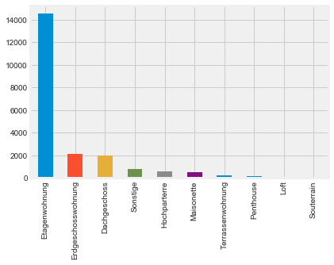

```python
train['apartment_type'].value_counts().plot(kind='bar' )
```

How can be notice from the above figure, 'Etagenwohnung' (that in english means 'Flat') is by far the most common value of 'apartment_type' and we could simply impute the missing values with the mode. Let's do that:

```python
#first create a column 'apartment_type_imputed'
train['apartment_type_imputed'] = pd.DataFrame(np.zeros((train.shape[0], 1)))
```

```python
var = 'apartment_type'
mode = train[var].mode()[0]
print(str(var) + ", mode = " + mode)
print("Count before imputing: " + str(train[var].count()))
#keep track of the variables that will be imputed
var_imputed = var + "_imputed"
train[var_imputed] = train.apply(lambda x : (1 if isinstance(x[var], float) else  0),axis=1)
train[var] = train.apply(lambda x : (mode if isinstance(x[var], float)  else  x[var]),axis=1)
print("Count after imputing: " + str(train[var].count()))
```

```
apartment_type, mode = Etagenwohnung
Count before imputing: 20983
Count after imputing: 25190
```

##### 'condition' variable:

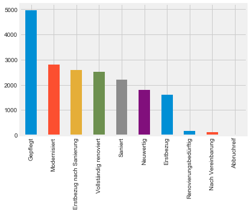

```python
train['condition'].value_counts().plot(kind='bar')
```

How can be notice from the above figure, 'Gepflegt' (that in english means 'refined' or 'elegant') is the most common value of 'condition', followed by 'Moderniest' ('Modern' in english), 'Erstbezug nach Sanierung' ('first tenants after renovation'), 'Vollstanding renoviert' ('Completely renovated'), 'Saniert' ('rehabilitate' or 'renovated') and 'Neuwertig' ('like new'). Before eventualy use the mode to impute the missing values, we should check if there is any particoular relationship between the variable 'condition' and other variables (i.e. 'building_year' for temporal relationship or 'latitude' and 'longitude' for spatial relationship).

```python
#define a dictionary of colors for visualization purposes
condition_colors = {}
condition_colors["Gepflegt"] = 'blue' # refined' or 'elegant
condition_colors["Modernisiert"] = 'green' #modern

condition_colors["Erstbezug nach Sanierung"] = 'yellow' #first tenants after renovation
condition_colors["Vollstanding renoviert"] = 'yellow' #Completely renovated
condition_colors["Saniert"] = 'yellow' #rehabilitate' or 'renovated

condition_colors["Erstbezug"] = 'red' #new
condition_colors["Neuwertig"] = 'red' #like new
```

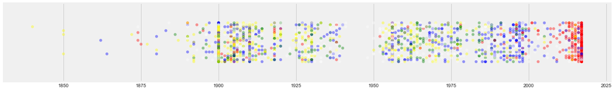

```python
import matplotlib
import random

#let's take a subsample of the training set (faster computation and more easy to visualize)
train_sample = train.sample(frac=0.1, random_state=1234).reset_index(drop=True)
fig, ax = matplotlib.pyplot.subplots(figsize=(20,3))
for index, row in train_sample.iterrows():
    x = row['building_year']
    y = 1 + random.randint(-10, 10) * 0.001 #add noise on y axis (in this way points do not overlap on the x axis)
    color = 'white'
    label = 'normal'
    if (row['condition'] in condition_colors):
        color = condition_colors[row['condition']]

    ax.scatter(x, y, c=color,
               alpha=0.4, edgecolors='none')

ax.get_yaxis().set_visible(False)
matplotlib.pyplot.show()
```

How can be notice from the picture above, there is a relationship between the 'condition' of the appartment and the 'building_year'. In partioular we can see that:

- NEW or LIKE NEW appartments ('Erstbezug' or 'Neuwertig') (red color) are quite predominant when building_year >=2010 (more or less);
- REFINED or ELEGANT appartments ('Gepflegt') (blue color) appear more often when 1990 <= building_year < 2010;
- MODERN ('Modernisiert') (green color) or 'renovated' ('Erstbezug nach Sanierung', 'Vollstanding renoviert', 'Saniert') (yellow color) appear more often when building_year < 1990.

Therefore, rather than impute the missing values for 'condition' simply with the mode, we could:

- set it as 'Neuwertig' (that overll appears more often than 'Erstbezug') when building_year >=2010;
- set it as 'Gepflegt' (actual mode of 'condition') when 1975 < building_year < 2010;
- set it as 'Modernisiert' (that overall appers more often than 'Erstbezug nach Sanierung' or 'Vollstanding renoviert') when building_year <= 1975;

Before doing that, let's check if there is also a spatial relationship between 'condition' and 'latitude' and 'longitude:

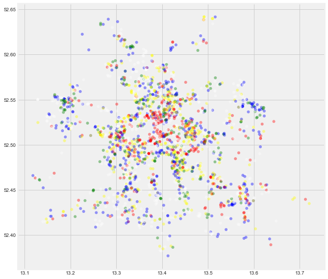

```python
#let's take a subsample of the training set (faster computation and more easy to visualize)
train_sample = train.sample(frac=0.1, random_state=4321).reset_index(drop=True)
fig, ax = matplotlib.pyplot.subplots(figsize=(10,10))
for index, row in train_sample.iterrows():
    x = row['longitude']
    y = row['latitude']
    color = 'white'
    label = 'normal'
    if (row['condition'] in condition_colors):
        color = condition_colors[row['condition']]

    ax.scatter(x, y, c=color,
               alpha=0.4, edgecolors='none')

matplotlib.pyplot.show()
```

From the figure above, we can notice that there is also a spatial relationship. In particoular it seems that 'refined' or 'elegant' houuses are more common in the outskirt. Anyway this relationship is not so evident as the temporal relationship, therefore we impute the missing values of 'condition' as mentioned before, taking into account 'building_year'.

```python
#first create a column 'condition'
train['condition_imputed'] = pd.DataFrame(np.zeros((train.shape[0], 1)))
```

```python
def get_condition_from_building_year(year):
    ''''Neuwertig' when building_year >=2010;
    'Gepflegt' when 1975 < building_year < 2010;
    'Modernisiert'  when building_year <= 1975;'''
    if (year<2010):
        if(year<= 1975):
            return 'Modernisiert'
        else:
            return 'Gepflegt'
    else:
        return 'Neuwertig'
```

```python
var = 'condition'
mode = train[var].mode()[0]
print(str(var) + ", mode = " + mode)
print("Count before imputing: " + str(train[var].count()))
#keep track of the variables that will be imputed
var_imputed = var + "_imputed"
train[var_imputed] = train.apply(lambda x : (1 if isinstance(x[var], float) else  0),axis=1)
train[var] = train.apply(lambda x : (get_condition_from_building_year(x['building_year']) if isinstance(x[var], float)  else  x[var]),axis=1)
print("Count after imputing: " + str(train[var].count()))
```

```
condition, mode = Gepflegt
Count before imputing: 18774
Count after imputing: 25190
```

##### 'interior_quality' variable:

Let's repeat the process we used for the variable 'condition' also for 'interior_quality'.  
Before doing so, let's check how 'interior_quality' is distributed:

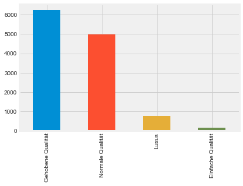

```python
train['interior_quality'].value_counts().plot(kind='bar', stacked = True)
```

We can notice that "Gehobene Qualität" ("High Quality") is the most common value, followed by "Normale Qualität" ("Normal quality").  
Let's check if there is a temporal relationship:

```python
#define colors for visualization
interior_quality_colors = {}
interior_quality_colors["Normale Qualität"] = 'red' # Normal quality
interior_quality_colors["Gehobene Qualität"] = 'blue' #High quality
interior_quality_colors["Einfache Qualität"] = 'green' #Simple quality
interior_quality_colors["Luxus"] = 'yellow' #Luxury
```

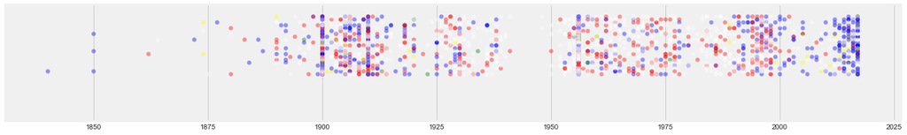

```python
#let's take a subsample of the training set (faster computation and more easy to visualize)
train_sample = train.sample(frac=0.1, random_state=1234).reset_index(drop=True)
fig, ax = matplotlib.pyplot.subplots(figsize=(20,3))
for index, row in train_sample.iterrows():
    x = row['building_year']
    #print(type(x))
    y = 1 + random.randint(-10, 10) * 0.001
    color = 'white'
    label = 'normal'
    if (row['interior_quality'] in interior_quality_colors):
        color = interior_quality_colors[row['interior_quality']]

    ax.scatter(x, y, c=color,
               alpha=0.4, edgecolors='none')

ax.get_yaxis().set_visible(False)
matplotlib.pyplot.show()
```

How can be notice from the picture above, there is a temporal relationship:

- High quality appartments ('Gehobene Qualität' in blue) are more common when building_year >= 2000 or when building_year <= 1925;
- Normal quality appartments ('Normale Qualitä' in red) are more common in between year 1975 and 2000.  
  Therefore, in a similar way as we did for 'condition', we impute the missing values for the variable 'interior_quality' in this way:
- if 1925 < building_year < 2000 --> 'Normale Qualitä';
- else 'Gehobene Qualität' (actual mode of 'interior_quality');

```python
def get_interior_quality_from_building_year(year):
    if (year>1925 and year<2000):
        return 'Normale Qualität'
    else:
        return 'Gehobene Qualität'
```

```python
#first create a column 'condition'
train['interior_quality_imputed'] = pd.DataFrame(np.zeros((train.shape[0], 1)))
```

```python
var = 'interior_quality'
mode = train[var].mode()[0]
print(str(var) + ", mode = " + mode)
print("Count before imputing: " + str(train[var].count()))
#keep track of the variables that will be imputed
var_imputed = var + "_imputed"
train[var_imputed] = train.apply(lambda x : (1 if isinstance(x[var], float) else  0),axis=1)
train[var] = train.apply(lambda x : (get_interior_quality_from_building_year(x['building_year']) if isinstance(x[var], float)  else  x[var]),axis=1)
print("Count after imputing: " + str(train[var].count()))
```

```
interior_quality, mode = Gehobene Qualität
Count before imputing: 12152
Count after imputing: 25190
```

We still need to impute the missing values for the variables 'district_id','zone_id', 'street', 'description'.

The variables 'district_id' and 'zone_id' only have 6 missing values (we could think to eliminate those instances).  
We impute:

##### Impute 'district_id':

```python
#first create a column 'apartment_type_imputed'
train['district_id_imputed'] = pd.DataFrame(np.zeros((train.shape[0], 1)))
```

```python
var = 'district_id'
mode = train[var].mode()
print(str(var) + ", mode = " + mode)
print("Count before imputing: " + str(train[var].count()))
#keep track of the variables that will be imputed
var_imputed = var + "_imputed"
train[var_imputed] = train.apply(lambda x : (1 if isinstance(x[var], float) else  0),axis=1)
train[var] = train.apply(lambda x : (train[train.zip_code == x['zip_code']][var].mode()[0] if isinstance(x[var], float)  else  x[var]),axis=1)
print("Count after imputing: " + str(train[var].count()))
```

```
0    district_id, mode = 11000000_4_006
dtype: object
Count before imputing: 25184
Count after imputing: 25190
```

##### Impute 'zone_id':

```python
#first create a column 'apartment_type_imputed'
train['zone_id_imputed'] = pd.DataFrame(np.zeros((train.shape[0], 1)))
```

```python
var = 'zone_id'
mode = train[var].mode()
print(str(var) + ", mode = " + mode)
print("Count before imputing: " + str(train[var].count()))
#keep track of the variables that will be imputed
var_imputed = var + "_imputed"
train[var_imputed] = train.apply(lambda x : (1 if isinstance(x[var], float) else  0),axis=1)
train[var] = train.apply(lambda x : ((train[var].mode()[0]) if isinstance(x[var], float)  else  x[var]),axis=1)
print("Count after imputing: " + str(train[var].count()))
```

```
0    zone_id, mode = 11000000_5_009
dtype: object
Count before imputing: 25184
Count after imputing: 25190
```

##### Impute 'street':

```python
#first create a column 'street_imputed'
train['street_imputed'] = pd.DataFrame(np.zeros((train.shape[0], 1)))
```

```python
def get_street(zip_code, district_id, zone_id):
    """retrieve street mode of the instances with given 'zip_code', 'district_id' and 'zone_id'
    in case of exception return the default mode"""
    try:
        mode = train[(train.zip_code == x['zip_code']) & (train.district_id == x['district_id']) & (train.zone_id == x['zone_id'])][var].mode()[0]
    except:
        mode = train['street'].mode()[0]
    return mode
```

```python
train['street'].describe()
```

```
count              20386
unique              5842
top       Chausseestraße
freq                  69
Name: street, dtype: object
```

```python
var = 'street'
mode = train[var].mode()[0]
print(str(var) + ", mode = " + mode)
print("Count before imputing: " + str(train[var].count()))
#keep track of the variables that will be imputed
var_imputed = var + "_imputed"
train[var_imputed] = train.apply(lambda x : (1 if isinstance(x[var], float) else  0),axis=1)
train[var] = train.apply(lambda x : ( get_street(x['zip_code'], x['district_id'], x['zone_id']) if isinstance(x[var], float)  else  x[var]),axis=1)
print("Count after imputing: " + str(train[var].count()))
```

```
street, mode = Chausseestraße
Count before imputing: 20386
Count after imputing: 25190
```

```python
train['street'].describe()
```

```
count              25190
unique              5842
top       Chausseestraße
freq                4873
Name: street, dtype: object
```

#### 1.3.1 Dealing with variable 'description':

Actually the variable 'description' (with a missing ratio of 11.4%) is not a CATEGORICAL variable but is free TEXT and should be treated in a different way.  
Let's take a look:

```python
train['description'].describe()
```

```
count                                                 22319
unique                                                18020
top       Extras:- Treppenhausreinigung- Hausmeisterserv...
freq                                                    300
Name: description, dtype: object
```

'description', as expected, has a huge number of unique values. The mode appears 300 times (300 instances in the training have the same description). Let's check the mode:

```python
train['description'].mode()[0]
```

```
'Extras:- Treppenhausreinigung- Hausmeisterservice- Winterdienst- Gegensprechanlage'
```

English translation: 'Extras: - Stairwell cleaning- Caretaker service- Winter maintenance- Intercom system'.  
How can we notice, the text contains a lot of information (in this case extras in the apartment).  
Let's analyze few more descriptions:

```python
train_sample = train.sample(frac=0.001, random_state=1234).reset_index(drop=True)
for index, row in train_sample.iterrows():
    print(index)
    x = row['description']
    print(x)
    print("------------")
```

```
0
funktionelle 3Raum Wohnung, ruhige Wohnung in kleiner Wohnanlage am Volkspark Mariendorf, verkehrsgünstig U6-Westphalweg, gute Infrastruktur,Objekt mit Vollwärmeschutz  ausgestattet
------------
1
Hier präsentieren wir Ihnen diese hochwertig ausgestattete 2-Zimmer-Wohnung mit einer Wohnfläche von ca. 50 m². Die im Hochparterre gelegene Wohnung ist frisch saniert und besticht mit neuen Fenstern und erstklassigem Echtholzparkett. Eine Einbauküche wird bis zum Einzug noch eingebaut.Die gut gesch…
------------
2
Die Mitte der 1980iger Jahre entstandenen Neubauten befinden sich in einem gepflegten Zustand. Die aufgelockerte Bebauung mit zahlreichen Grünflächen und liebevoll gestalteten Innenhöfen vermitteln eine hohe Aufenthalts- und Wohnqualität. Ausreichend Stellplätze sind in der nahen Umgebung vorhanden.…
------------
3
Ruhige 2-Zimmer-Wohnung in West-Ausrichtung im Seitenflügel eines 2009 saniertem und modernisierten Gründerzeit-Altbau nahe S- und U-Bahnhof Schönhauser Allee.
------------
4
Hochwertig sanierter Altbau!Im Vorderhaus eines liebevoll sanierten Altbaus wartet diese Wohnung darauf, Ihr neues Zuhause zu werden. Die Gärtnerstrasse 3 liegt im eher ruhigen Teil von Friedrichshain unweit des Boxhagener Platzes.Mit einem Personenaufzug gelangen Sie bequem in das 3. Obergeschoss. …
------------
5
Hinweis: Beispielfotos einer ähnlichen Wohnung.Das denkmalgeschützte Areal der ehemaligen "Glanzfilmfabrik" wurde, im klassischen Backstein-Stil, 1923 erbaut. Alle Häuser wurden und werden auf hohem Niveau komplett saniert und bieten nun einen gehobenen und modernen Wohnkomfort. Diese einzigartigen …
------------
6
Diese Wohnung im Herzen Berlins hat nicht nur eine große Terrasse zu bieten, sondern auch zusätzlich zwei Bäder und eine Einbauküche. Ausblicke haben Sie natürlich auch in den Räumen der Wohnung. Hier sorgen bodentiefen Fenster für viel Licht und gute Laune. Der raumeffiziente Grundriss der Wohnung …
------------
7
Die 2-Zimmerwohnung befindet sich in absoluter Bestlage in Kreuzberg im 3. Obergeschoss des frisch fertiggestellten Neubaus. Da das Objekt im Innenhof mit eigener  Grünfläche gelegen ist, ist nicht nur der Ausblick Entspannung pur, sondern auch die ruhige Lage. Mit einem Fahrstuhl gelangen Sie in di…
------------
8
nan
------------
9
Besichtigung: Freitag, 27.07.2018, 15 UhrWohnung im Vorderhaus 3. Obergeschoß
------------
10
Das Wohnhaus Raschdorffstr. 16 verfügt über einen begrünten Innenhof. Zusätzlich verfügt die Anlage über Garagenplätze und bietet somit eine bequeme Abstellmöglichkeit für das Auto. Die Wohnungen haben einen Balkon und haben unterschiedliche Schnitte. Die Umgebung bietet eine große Auswahl an Geschä…
------------
11
Diese schöne Wohnung befindet sich im Hochparterre in einem sehr gepflegten ruhigen Haus. Die Räume sind modern, hell und lichtdurchflutet. Die Wohnung wurde 2016 komplett saniert und modernisiert: Neue Elektrik, neue Fenster, elektrische Funk-Außenjalousien. Bad und Küche neu gefliest, hochwertiges…
------------
12
Eckdaten: Objekt Rodenbergstr. 49 in 10439 Berlin Wohnung Vorderhaus, 1. OG links/2009 WE 0013Größe ca. 50,01 m² Zimmer 2 / Küche, Flur, Duschbad, Toilette, Balkon, KellerraumHeizung GasetzentralNetto / Kalt 600,00 € Betriebskosten 75,00 €Heizkosten 75,00 €Gesamtmiete 750,00 € Mietbeginn 15.03.2018/…
------------
13
```

[output cut: 20 more lines]

```
20
Ich suche für meine Altbau, Zwei Zimmer Wohnung (Durchgangszimmer) im Hochparterre einen Nachmieter ab sofort. Die Wohnung ist auf der Reichenberger Straße direkt am Kottbusser Tor. Die EBK wurde gerade erst eingebaut und muss daher übernommen werden (ca. 1.400 Euro).  Mit Herd, aber ohne Kühlschran…
------------
21
Diese extravagante Wohnung liegt in einem Baudenkmal im sogenannten Westfälischen Viertel in einem ehemaligen Schulgebäude der Techniker Schule.Der Charakter des roten Backsteinbaus aus dem Jahre 1907 wurde in die Wohneinheit übertragen.
------------
22
Die angebotene 2-Zimmerwohnung befindet sich im Erdgeschoss des Hauses Eldenaer Straße 2 in 10247 Berlin-Friedrichshain.
------------
23
Diese ansprechende, neuwertige Wohnung zeichnet sich durch eine gehobene Innenausstattung aus und kann ab sofort bezogen werden. Zwei Badezimmer und ein separates Gäste-WC zählen neben drei schönen Zimmern zu dem Objekt. Die letzte Modernisierung fand erst vor Kurzem, im Jahr 2017, statt. Zu einem g…
------------
24
WBS-Erforderlich. Eine Anmietung mit mehr als 2 Personen ist in diesem Objekt leider nicht möglich.Diese Wohnung liegt in einem Altbau von 1910. Der Altbaucharme zeigt sich in den alten schönen Wohnungstüren, dem Dielenboden und dem erhalten gebliebenen Stuck. Die Wohnung bietet Ihnen helle und groß…
------------
```

##### English translation for the first 7 considered examples

0

## - Functional 3-room apartment, quiet apartment in a small residential complex at Volkspark Mariendorf, conveniently located U6-Westphalweg, good infrastructure, property with full thermal insulation

1

## - Here we present this high-quality 2-room apartment with a living space of approx. 50 m². The apartment on the mezzanine floor is freshly renovated and impresses with new windows and first-class real wood parquet. A fitted kitchen will be installed until the move in. The well-designed rooms are flooded with light through the large window surfaces. High-quality recessed ceiling lights guarantee a bright and warm living flair in the hallway and in the bathroom. Another highlight is the balcony to the green courtyard with a view of the Dahme. Here holiday feelings arise! The bathroom is also completely new and convinces with a bathtub shower and towel heating. The communal garden and a 10 m² private cellar compartment complete the attractive overall package. Thanks to the quiet location on the Dahme you can switch off perfectly from the hectic city life and yet everyone Advantages of the metropolis benefit!

2

## - The new buildings that were built in the mid-1980s are in good condition. The loosened up buildings with numerous green areas and lovingly designed courtyards convey a high quality of living and living. There are sufficient parking spaces in the vicinity. The property is supplied by district heating, the rent already includes the basic fee for cable television. It is possible to use a fully digital TV connection with high-speed Internet access. You can find more information and offers at www.wohnen-in-hellersdorf.de

3

## - Quiet west-facing 2-room apartment in the side wing of an old building from the Wilhelminian period, renovated and modernized in 2009 near the Schönhauser Allee S-Bahn and U-Bahn station.

4

## - In the front building of a lovingly renovated old building, this apartment is waiting to become your new home. Gärtnerstrasse 3 is located in the rather quiet part of Friedrichshain not far from Boxhagener Platz. You can easily get to the 3rd floor with a passenger elevator. The apartment is bright and has a well-designed floor plan. You enter the apartment and are in the large (approx. 36 m²) living area. The kitchen is integrated here. It forms the communication center of your new apartment. From the living area you can access the two bedrooms, which are roughly the same size. The balcony facing the street borders one of the bedrooms. To the other bedroom is the balcony facing the courtyard. The modern bathroom has 2 sinks, a bathtub, toilet and washing machine connection.

5

## - Note: Example photos of a similar apartment. The listed area of the former "glossy film factory" was built in classic brick style in 1923. All houses have been and will be completely renovated at a high level and now offer upscale and modern living comfort. These unique factory buildings are surrounded by water on almost all sides and house a historic park. Due to the charming mix of nature and architecture, you will find a high quality of life paired with an unmistakable charm. Please note that these are sample pictures of the same apartment from the 3rd floor before renting. Thanks a lot.

6

- This apartment in the heart of Berlin not only has a large terrace to offer, but also two bathrooms and a fitted kitchen. Of course you also have views in the rooms of the apartment. Floor-to-ceiling windows provide plenty of light and a good mood. The space-efficient floor plan of the apartment is a real stroke of luck. The center of gravity, however, is the representative kitchen-dining area, which also gives access to the large terrace. With two more quiet rooms, a master bath and another shower bath, a relaxed start to the day is ensured, even if you have guests. Attention! They will always be happy to come back once they have benefited from this great city residence. The high-quality new building from 2017 got a perfectly coordinated facade design. The interior of the building welcomes its residents with a subtle, pleasant lighting mood and high-quality materials. The PANDION Cosmopolitan can refer to good addresses here: Gendarmenmarkt, Museum Island, Friedrichstrasse, Schlossplatz, Nikolaiviertel and Potsdamer Platz are within walking distance and are interested in them Real estate, have questions about financing or would like an appointment? The ZIEGERT team is always happy to help!

The descriptions contain a lot of information. Unfortunately the information is unstructured and we need to find a way to extract structured relevant information.  
When dealing with text there are several possible approaches:

- use a bag of word model where we keep tract of which word is contained in the text and wich not
- use word embedings and map words in the text to vectors.

Unfortunately these approaches have 2 main problems in this context:  
1) using these approaches the number of input features will drastically increase (bag of word generates a sparse vector with the dimension of the vocaboulary size, word embedding use vectors which common dimension is 300)  
2) the text is in german (not in english) and a lot of libriries for the mentioned approaches are available only in english (i.e. text preprocessing libraries used for word embedding are difficult to find for languages that are not english, the pre-trained wort embeddings algorithms are trained on english text corpus).

Therefore, we need a way to extract relevant information from the text, without increasing too much the number of input features.

The fist thing we can do is to keep track of wich instance contains a description and which not:

```python
#replace nan descriptions with the null String
var = 'description'
print("Count before imputing: " + str(train[var].count()))
#keep track of the description that are missing
var_imputed = var + "_missing"
train[var_imputed] = train.apply(lambda x : (1 if isinstance(x[var], float) else  0),axis=1)
train[var] = train.apply(lambda x : ( "" if isinstance(x[var], float)  else  x[var]),axis=1)
print("Count after imputing: " + str(train[var].count()))
```

```
Count before imputing: 22319
Count after imputing: 25190
```

A possible solution for the problem mentioned above is:

- we find the words contained in the descriptions that are more discriminative for high or low 'price_m2'.
- we select the n (i.e. 10) most discriminative words and we use n binary variables (word1_contained, ..., wordn_contained) to keep track of which description contains these words.

In this way we use an approach similar to bag of word models but we limit the additional number of features to n (rather than the entire vocaboulary size)

First of all we vectorize all the words contained in the description. We use TfidfVectorizer by sklearn that uses spars matrices (faster computation).

```python
from time import time
from sklearn.feature_extraction.text import TfidfVectorizer
from sklearn.feature_selection import SelectKBest, chi2
```

```python
print("Extracting features from the training data using a sparse vectorizer by sklearn...")
t0 = time()

vectorizer = TfidfVectorizer(sublinear_tf=True, max_df=0.5)
#we only consider the instances where description is not empty
description_train = vectorizer.fit_transform(train[train.description != ""]['description'])
duration = time() - t0
print("done in %fs"  %(duration))
print("n_samples: %d, n_features: %d" % description_train.shape)
print()
```

```
Extracting features from the training data using a sparse vectorizer by sklearn...
done in 1.194155s
n_samples: 22319, n_features: 37518
```

```python
feature_names = vectorizer.get_feature_names()
print("Vocaboulary size: " + str(len(feature_names)))
```

```
Vocaboulary size: 37518
```

How can we notice, the vocauboulary size is huge and we cannot consider all the possible contained words. Therefore, we use a chi-squared test to select the most discriminative words. **Note:** The chi-squared test works with classification, therefore we use a dummy variable 'above_average' that keeps track of which instance has a TARGET VARIABLE value above the average. In this way, the chi-squared test finds the most discriminative words for values of the TARGET above or below the average.

```python
#compute mean and create the variable 'above_average'
#we actually use the LOG_TARGET that has a distribution more similar to a Gaussian distribution.
mean = train[LOG_TARGET].mean()
train['above_average'] = train.apply(lambda x : (1 if x[LOG_TARGET]>mean else  0),axis=1)
train['above_average'].describe()
```

```
count    25190.000000
mean         0.478166
std          0.499533
min          0.000000
25%          0.000000
50%          0.000000
75%          1.000000
max          1.000000
Name: above_average, dtype: float64
```

```python
#we now retrieve the most important words with respect to the variable 'above_average'
print("Extracting best features by a chi-squared test")
t0 = time()
ch2 = SelectKBest(chi2) #default K = 10
description_train = ch2.fit_transform(description_train,train[train.description != ""]['above_average'])
#X_test = ch2.transform(X_test)
if feature_names:
    # keep selected feature names
    feature_names = [feature_names[i] for i in ch2.get_support(indices=True)]
print("done in %fs" % (time() - t0))
print()
```

```
Extracting best features by a chi-squared test
done in 0.070811s
```

##### Let's check which are the 10 most discriminative words:

```python
feature_names
```

```
['allgemein',
 'breitbandkabelanschluss',
 'extras',
 'gegensprechanlage',
 'hausmeisterservice',
 'neuextras',
 'treppenhausreinigung',
 'winterdienst',
 'wohnanlage',
 'wärmedämmungextras']
```

English translation:

- 'general', - 'broadband cable connection', - 'extras', - 'intercom', - 'caretaker service', - 'new extras', - 'staircase cleaning', - 'winter service', - 'condominium', - 'thermal insulation extras']

Ok, these are the most discriminative words we found. We actually merge 'extras' and 'new extras' into 'extras' and we exclude the word 'allgemein' ('general') because of little significance in the context. Therefore we create 8 binary features that keep tract of the fact that each of the selected word is contained in the description or not:

```python
#we stemm (try to extract the root form of the word)
#some of thise words in orther to improve the recall inside the description
discriminative_words = ['kabelanschluss','extra','sprechanlag',
                         'hausmeister', 'treppenhausreinigun', 'winterdienst',
                         'wohnanlage','wärmedämmung']
```

```python
def is_contained(word, text):
    """return True if word is contained in lowercase text"""
    if word in text.lower():
        return True
    return False
```

```python
for word in discriminative_words:
    print(word)
    var = word + "_IsContained"
    #set the corresponding variable to 1 if word is contained in description, 0 otherwise
    train[var] = train.apply(lambda x : ( 1 if is_contained(word, x['description'])  else  0),axis=1)
```

```
kabelanschluss
extra
sprechanlag
hausmeister
treppenhausreinigun
winterdienst
wohnanlage
wärmedämmung
```

```python
#check how many examples contain such words in the description
for word in discriminative_words:
    var = word + "_IsContained"
    print(str(round(train[var].mean() * 100,2)) + '% of descript. contain: ' + word)
```

```
1.75% of descript. contain: kabelanschluss
3.28% of descript. contain: extra
4.34% of descript. contain: sprechanlag
3.05% of descript. contain: hausmeister
2.58% of descript. contain: treppenhausreinigun
2.33% of descript. contain: winterdienst
8.54% of descript. contain: wohnanlage
1.05% of descript. contain: wärmedämmung
```

#### Let's check if there is still some variable with missing values:

```python
#check the count of each variable
count = train.describe(include = 'all').T['count']
count[count < train.shape[0]]
```

```
ended_at         24840
street_number    20214
Name: count, dtype: object
```

There are still 'ended_at' and 'street_number' with some missing values. Regarding 'ended_at' we impute it as 'posted_at' + 'num_days'.  
Before doing that, we notice that 'posted_at' and 'ended_at' are strings representing dates, which minimum date is '2018-01-01'.  
The procedure we apply is the following:

- convert 'posted_at' in the number of days between '2018-01-01' (start date) and posted_at_date
- convert 'ended_at' in the sum of dys 'posted_at' + 'num_days'

```python
def get_days(date_string):
    """return the number of days between start_date and date_string"""
    start_date = datetime.strptime('2018-01-01', '%Y-%m-%d').date()
    date = datetime.strptime(date_string, '%Y-%m-%d').date()
    delta = date - start_date
    return delta.days
```

```python
#let's analize 'num_days' first
train['num_days'].describe()
```

```
count    25190.000000
mean        27.735292
std         31.238183
min       -181.000000
25%          5.000000
50%         15.000000
75%         41.000000
max        108.000000
Name: num_days, dtype: float64
```

There is some outliers (num_days cannot be negative): we substitute them with the median.

```python
var = 'num_days'
median = train['num_days'].median()
train[var] = train.apply(lambda x : median if x['num_days'] <= 0 else x['num_days'],axis=1)
```

```python
train['num_days'].describe()
```

```
count    25190.000000
mean        29.101429
std         30.269387
min          1.000000
25%          8.000000
50%         15.000000
75%         41.000000
max        108.000000
Name: num_days, dtype: float64
```

Ok, not it looks better.

```python
from datetime import datetime
var = 'posted_at'
train[var] = train.apply(lambda x : get_days(x['posted_at']),axis=1)
```

```python
var = 'ended_at'
train[var] = train.apply(lambda x : x['posted_at'] + x['num_days'],axis=1)
```

```python
train['posted_at'].describe()
```

```
count    25190.000000
mean       172.394958
std        104.000526
min          1.000000
25%         80.000000
50%        164.000000
75%        270.000000
max        364.000000
Name: posted_at, dtype: float64
```

```python
train['ended_at'].describe()
```

```
count    25190.000000
mean       201.496387
std        109.582316
min          2.000000
25%        112.000000
50%        190.000000
75%        312.000000
max        432.000000
Name: ended_at, dtype: float64
```

The variables 'posted_at' and 'ended_at' do not show outliers.

Finally, regarding the variable 'street_number', I decide to not consider it because is a string object that contains numbers and letters and some preprocessing would be needed but I consider the variable of little significance.

```python
#drop 'street_number'
print(train.shape)
train = train.drop('street_number', axis = 1)
print(train.shape)
```

```
(25190, 52)
(25190, 51)
```

### 1.4 Recap:

Let's do a recap of what we did with the training set.  
For the numerical variabes:

- we tried to detect outliers (i.e. 'num_rooms' sometime has a value of 170 that is not feasible for and apartment) and replace them with the 95% quantile;
- we analyzed the distribution of missing values;
- we checked if we could impute 'num_bedrooms' using the eq. num_rooms = num_bathrooms + num_bedrooms, but we had to exclude this assumption;
- we impute the missing values with the median.
- we kept track of which variable we imputed.

For text the variable 'description':

- we kept track of which instance have or does not have a description;
- we tried to find the most dicriminative words using a chi-squared test and the variable 'above_average' without drammatically increase the number of input variables;
- we kept track, for each of the words we found (8 in total), wich instance contains the word in the description

Finally:

- we replaced some outliers in 'num_days' with the medin
- we converted 'posted_at' in the number of days between '2018-01-01' (start date) and posted_at_date
- we converted 'ended_at' in the sum of days 'posted_at' + 'num_days'
- we dropped 'street_number'

Now, before further proceding with the analysis, **let's apply the same procedure to the test.**  
**Note:** When imputing the missing values on the test, we use the median/mode computed over the train (otherwise we would cheat!)

```python
#eliminate examples where target variable is nan or  target variable is <= 0
print(test.shape)
test = test[test.price_m2 > 0]
test.shape
```

```
(10800, 27)
```

```
(10796, 27)
```

```python
#create new column applying log scale to the TARGET variable
test['log_price_m2'] = test.apply(lambda x : math.log10(x[TARGET]),axis=1)
```

```python
NUM_FEATURES = [ 'area', 'building_year', 'num_days',
                 'floor', 'num_rooms', 'living_space', 'num_bedrooms',
                'num_bathrooms', 'num_floors',]
```

```python
#quantile
for var in NUM_FEATURES:
    quantlile95 = train[var].quantile(.95)
    test[var] = test.apply(lambda x : (quantlile95 if x[var] > quantlile95   else  x[var]),axis=1)
```

```python
NUM_FEATURES.extend(['latitude', 'longitude'])
```

```python
#create a column 'variableName_imputed' for each variable in NUM_FEATURES
print(test.shape)
for var in NUM_FEATURES:
    var_imputed = var + "_imputed"
    test[var_imputed] = pd.DataFrame(np.zeros((test.shape[0], 1)))
print(test.shape)
```

```
(10796, 28)
(10796, 39)
```

```python
for var in NUM_FEATURES:
    print(str(var) + ":")
    print("Count before imputing: " + str(test[var].count()))
    computed_median = train[var].median(skipna = True)
    #keep track of the variables that will be imputed
    var_imputed = var + "_imputed"
    test[var_imputed] = test.apply(lambda x : (1 if math.isnan(x[var])  else  0),axis=1)
    test[var] = test.apply(lambda x : (computed_median if math.isnan(x[var])  else  x[var]),axis=1)
    print("Count after imputing: " + str(test[var].count()))
    print()
```

```
area:
Count before imputing: 10796
Count after imputing: 10796

building_year:
Count before imputing: 8830
Count after imputing: 10796

num_days:
Count before imputing: 10630
Count after imputing: 10796

floor:
Count before imputing: 9346
Count after imputing: 10796

num_rooms:
Count before imputing: 10760
Count after imputing: 10796

living_space:
Count before imputing: 10388
Count after imputing: 10796

num_bedrooms:
Count before imputing: 4555
Count after imputing: 10796

num_bathrooms:
Count before imputing: 7013
Count after imputing: 10796

num_floors:
Count before imputing: 6313
Count after imputing: 10796

latitude:
Count before imputing: 10729
Count after imputing: 10796

longitude:
Count before imputing: 10729
Count after imputing: 10796
```

```python
#drop useless columns
print("test shape: " + str(test.shape))
test = test.drop(['property_type_id', 'market_type', 'city_id'], 1)
print("test shape: " + str(test.shape))
```

```
test shape: (10796, 39)
test shape: (10796, 36)
```

```python
CAT_FEATURES = ['zip_code','district_id', 'zone_id', 'street', 'apartment_type', 'condition', 'interior_quality', 'description']
```

```python
#first create a column 'apartment_type_imputed'
test['apartment_type_imputed'] = pd.DataFrame(np.zeros((test.shape[0], 1)))
```

```python
#imput apartment_type
var = 'apartment_type'
mode = train[var].mode()[0]
print(str(var) + ", mode = " + mode)
print("Count before imputing: " + str(test[var].count()))
#keep track of the variables that will be imputed
var_imputed = var + "_imputed"
test[var_imputed] = test.apply(lambda x : (1 if isinstance(x[var], float) else  0),axis=1)
test[var] = test.apply(lambda x : (mode if isinstance(x[var], float)  else  x[var]),axis=1)
print("Count after imputing: " + str(test[var].count()))
```

```
apartment_type, mode = Etagenwohnung
Count before imputing: 8985
Count after imputing: 10796
```

```python
#impute condition
var = 'condition'
mode = train[var].mode()[0]
print(str(var) + ", mode = " + mode)
print("Count before imputing: " + str(test[var].count()))
#keep track of the variables that will be imputed
var_imputed = var + "_imputed"
test[var_imputed] = test.apply(lambda x : (1 if isinstance(x[var], float) else  0),axis=1)
test[var] = test.apply(lambda x : (get_condition_from_building_year(x['building_year']) if isinstance(x[var], float)  else  x[var]),axis=1)
print("Count after imputing: " + str(test[var].count()))
```

```
condition, mode = Modernisiert
Count before imputing: 7928
Count after imputing: 10796
```

```python
#first create a column 'condition'
test['interior_quality_imputed'] = pd.DataFrame(np.zeros((test.shape[0], 1)))
```

```python
#impute interior_quality
var = 'interior_quality'
mode = train[var].mode()[0]
print(str(var) + ", mode = " + mode)
print("Count before imputing: " + str(test[var].count()))
#keep track of the variables that will be imputed
var_imputed = var + "_imputed"
test[var_imputed] = test.apply(lambda x : (1 if isinstance(x[var], float) else  0),axis=1)
test[var] = test.apply(lambda x : (get_interior_quality_from_building_year(x['building_year']) if isinstance(x[var], float)  else  x[var]),axis=1)
print("Count after imputing: " + str(test[var].count()))
```

```
interior_quality, mode = Normale Qualität
Count before imputing: 5159
Count after imputing: 10796
```

```python
#impute district_id
var = 'district_id'
mode = train[var].mode()
print(str(var) + ", mode = " + mode)
print("Count before imputing: " + str(test[var].count()))
#keep track of the variables that will be imputed
var_imputed = var + "_imputed"
test[var_imputed] = test.apply(lambda x : (1 if isinstance(x[var], float) else  0),axis=1)
test[var] = test.apply(lambda x : (test[test.zip_code == x['zip_code']][var].mode()[0] if isinstance(x[var], float)  else  x[var]),axis=1)
print("Count after imputing: " + str(test[var].count()))
```

```
0    district_id, mode = 11000000_4_006
dtype: object
Count before imputing: 10794
Count after imputing: 10796
```

```python
#impute zone_id
var = 'zone_id'
mode = train[var].mode()
print(str(var) + ", mode = " + mode)
print("Count before imputing: " + str(test[var].count()))
#keep track of the variables that will be imputed
var_imputed = var + "_imputed"
test[var_imputed] = test.apply(lambda x : (1 if isinstance(x[var], float) else  0),axis=1)
test[var] = test.apply(lambda x : ((test[var].mode()[0]) if isinstance(x[var], float)  else  x[var]),axis=1)
print("Count after imputing: " + str(test[var].count()))
```

```
0    zone_id, mode = 11000000_5_009
dtype: object
Count before imputing: 10794
Count after imputing: 10796
```

```python
#first create a column 'street_imputed'
test['street_imputed'] = pd.DataFrame(np.zeros((train.shape[0], 1)))
```

```python
#impute street
var = 'street'
mode = train[var].mode()[0]
print(str(var) + ", mode = " + mode)
print("Count before imputing: " + str(test[var].count()))
#keep track of the variables that will be imputed
var_imputed = var + "_imputed"
test[var_imputed] = test.apply(lambda x : (1 if isinstance(x[var], float) else  0),axis=1)
test[var] = test.apply(lambda x : ( get_street(x['zip_code'], x['district_id'], x['zone_id']) if isinstance(x[var], float)  else  x[var]),axis=1)
print("Count after imputing: " + str(test[var].count()))
```

```
street, mode = Chausseestraße
Count before imputing: 8675
Count after imputing: 10796
```

```python
#replace nan descriptions with the null String
var = 'description'
print("Count before imputing: " + str(test[var].count()))
#keep track of the description that are missing
var_imputed = var + "_missing"
test[var_imputed] = test.apply(lambda x : (1 if isinstance(x[var], float) else  0),axis=1)
test[var] = test.apply(lambda x : ( "" if isinstance(x[var], float)  else  x[var]),axis=1)
print("Count after imputing: " + str(test[var].count()))
```

```
Count before imputing: 9591
Count after imputing: 10796
```

```python
for word in discriminative_words:
    print(word)
    var = word + "_IsContained"
    #set the corresponding variable to 1 if word is contained in description, 0 otherwise
    test[var] = test.apply(lambda x : ( 1 if is_contained(word, x['description'])  else  0),axis=1)
```

```
kabelanschluss
extra
sprechanlag
hausmeister
treppenhausreinigun
winterdienst
wohnanlage
wärmedämmung
```

```python
#replace outliers in 'number_days'
var = 'num_days'
median = train['num_days'].median()
test[var] = test.apply(lambda x : median if x['num_days'] <= 0 else x['num_days'],axis=1)
```

```python
#convert 'posted_at'
var = 'posted_at'
test[var] = test.apply(lambda x : get_days(x['posted_at']),axis=1)
```

```python
#convert 'ended_at'
var = 'ended_at'
test[var] = test.apply(lambda x : x['posted_at'] + x['num_days'],axis=1)
```

```python
#drop 'street_number'
print(test.shape)
test = test.drop('street_number', axis = 1)
print(test.shape)
```

```
(10796, 51)
(10796, 50)
```

Ok, we applyed the procedure also to the test. Let's procede further with the analysis:

### 1.5 Analyzing how imput variables behave with respect to TARGET - Feature Engineering

```python
print(NUM_FEATURES)
```

```
['area', 'building_year', 'num_days', 'floor', 'num_rooms', 'living_space', 'num_bedrooms', 'num_bathrooms', 'num_floors', 'latitude', 'longitude']
```

```python
NUM_FEATURES.extend([TARGET,LOG_TARGET])
```

```python
#Let's consider, for visualization purposes, only a portion of the dataset
#(it would be difficult to visualize 25k points at the same time)
train_sample = train.sample(frac=0.005, random_state=1234).reset_index(drop=True)
```

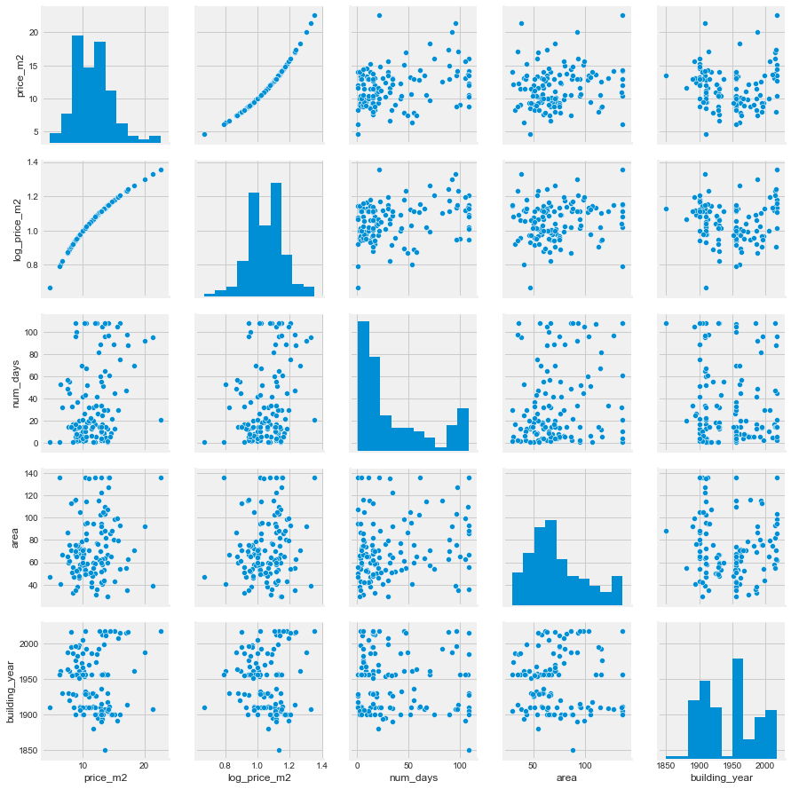

```python
#Let's check how 'area', 'building_year', 'num_days' behave with respect to the target
sns.pairplot(train_sample[[TARGET,LOG_TARGET,'num_days','area', 'building_year']])
```

##### Can we spot any relevant relationship (except between TARGET and LOG_TARGET)?

Let's focus on 'building_year':

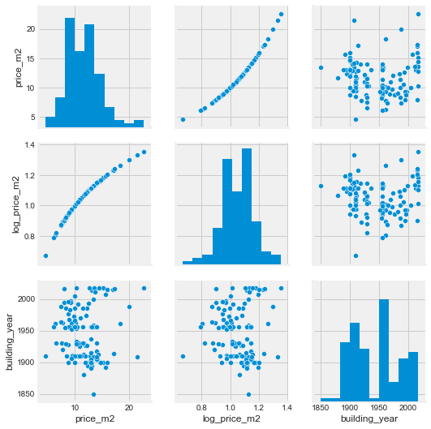

```python
sns.pairplot(train_sample[[TARGET,LOG_TARGET, 'building_year']])
```

Do you agree that there is a small parabolic relationship between 'building_year' and TARGET/LOG_TARGET? This means that TARGET could be aproximated as ax^2 + bx + c, where x is 'building_year'. A possible explanation for that is:

- new apartments have a better quality than others
- old appartments have been restored/rehabilitated
- apartments that are neither old nor new have a lower quality.

Therefore, in our analysis we should include a new feature 'building_year^2' that could be possibly usefull.

```python
#create new variable 'building_year_^2'
var = 'building_year_^2'
train[var] = train.apply(lambda x : np.square(x['building_year']-train['building_year'].mean()),axis=1)
```

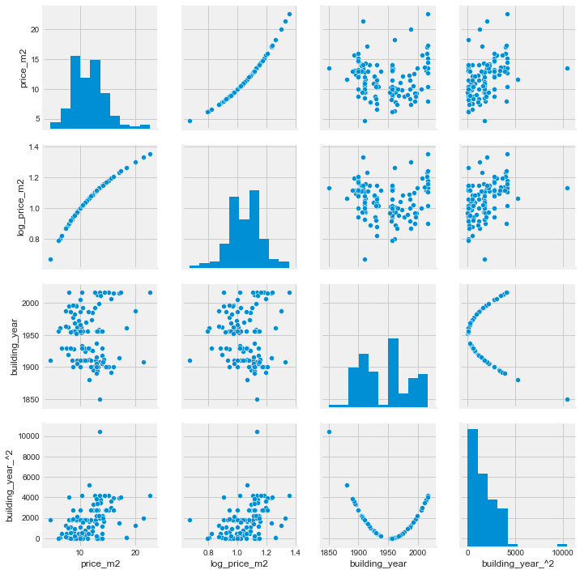

```python
train_sample = train.sample(frac=0.005, random_state=1234).reset_index(drop=True)
sns.pairplot(train_sample[[TARGET,LOG_TARGET, 'building_year', 'building_year_^2']])
```

##### Let's check how 'posted_at', 'ended_at', 'num_days', behave with respect to the target

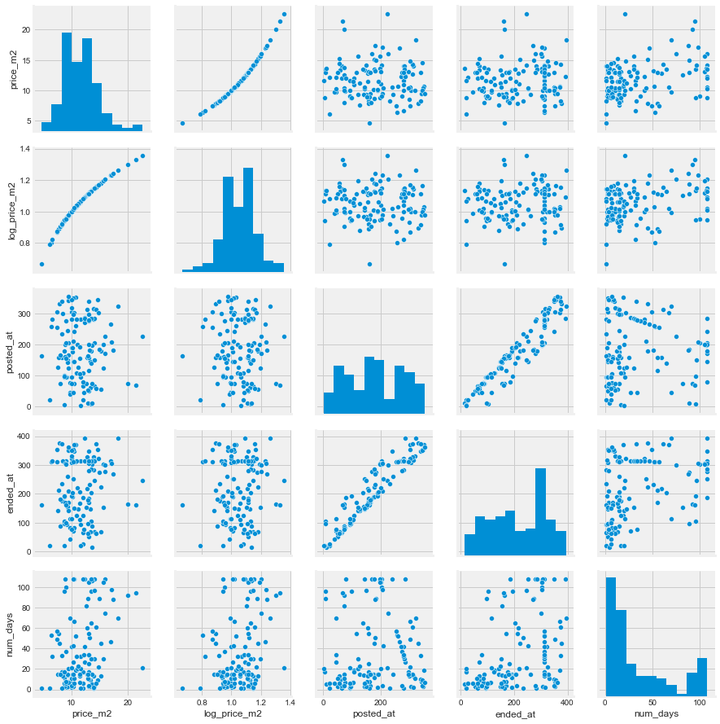

```python
#Let's check how 'posted_at', 'ended_at', 'num_days', behave with respect to the target
train_sample = train.sample(frac=0.005, random_state=1234).reset_index(drop=True)
sns.pairplot(train_sample[[TARGET,LOG_TARGET, 'posted_at', 'ended_at', 'num_days']])
```

We can notice that 'posted_at' and 'ended_at' have a strong linear relation, that's also because we computed 'ended_at' as the sum of 'posted_at' and 'num_days'. We drop therefore one of the 2 variables ('ended_at').  
Apart from that, I cannot spot any other relevant relationship. Just maybe a small linear relation between the target and 'num_days'.

```python
print(train.shape)
train = train.drop('ended_at', axis = 1)
print(train.shape)
```

```
(25190, 52)
(25190, 51)
```

##### Let's check how , 'num_rooms', 'living_space', 'num_bedrooms', 'num_bathrooms', behave with respect to the target

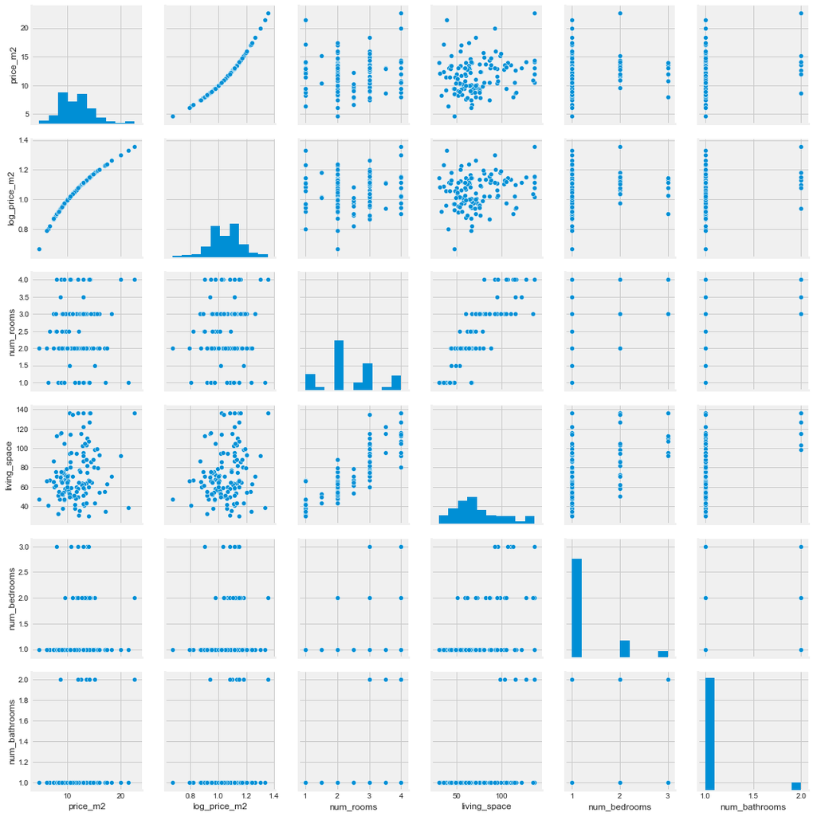

```python
#Let's check how , 'num_rooms', 'living_space', 'num_bedrooms', 'num_bathrooms',  behave with respect to the target
sns.pairplot(train_sample[[TARGET,LOG_TARGET, 'num_rooms', 'living_space', 'num_bedrooms', 'num_bathrooms']])
```

At first glance I cannot spot any relevant relationship.

Let's try to include in our analysis also some categorical/binary varaible:

##### How the TARGET behave with respect to the binary variable 'description_missing'?

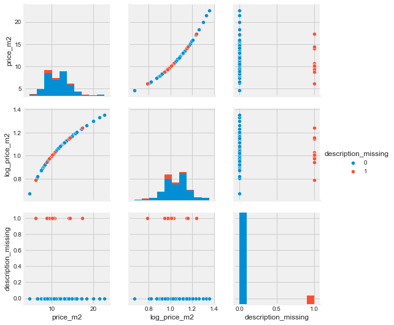

```python
sns.pairplot(train_sample[[TARGET,LOG_TARGET,'description_missing']], hue="description_missing")
```

Can you notice that is difficult to find expensive apartments when the description is missin?! This means that the binary variable could be a good predictor for the TARGET variable.

##### What if the quantity of provided information (the number of input variables that are not missing) is a good indicator of the price of an apartment?

Let's check if we have a similar behavior when, rather than 'description_missing', we analyze if a variable is been imputed or not.  
Let's consider 'num_floors' for example:

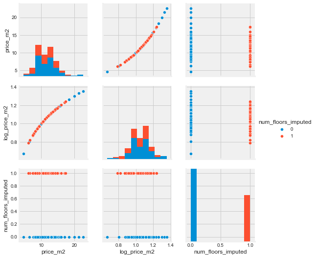

```python
sns.pairplot(train_sample[[TARGET,LOG_TARGET,'num_floors_imputed']], hue="num_floors_imputed")
```

The results suggest that the binary variables of the type "var_imputed" are good descriptors of the TARGET VARIABLE.  
The problem is that in total we have 18 binary features of this type (see below).  
Can we select, in some way, only the most important ones?  
The answer is yes and, similarly of what we did with the most discriminative words inside the description, we use a **chi-squared test.**  
This is an example of **feature selection/elimination** . Reducing the number of considered features (filtering out the less relevants) help to reach better performance and reduce the probability of overfitting.  
There are several techniques in order to perform feature selection but let's skip this discussion for now.

```python
#define a list of binary features on which perform feature selection
binary_imputetation_features = ['area_imputed',
       'building_year_imputed', 'num_days_imputed', 'floor_imputed',
       'num_rooms_imputed', 'living_space_imputed', 'num_bedrooms_imputed',
       'num_bathrooms_imputed', 'num_floors_imputed', 'latitude_imputed',
       'longitude_imputed', 'apartment_type_imputed', 'condition_imputed',
       'interior_quality_imputed', 'district_id_imputed', 'zone_id_imputed',
       'street_imputed', 'description_missing']
print(len(binary_imputetation_features))
```

```
18
```

```python
#we now retrieve the most important binary variables with respect to the variable 'above_average'
print("Extracting best binary variables by a chi-squared test")
t0 = time()
ch2 = SelectKBest(chi2) #default K = 10
description_train = ch2.fit_transform(train[binary_imputetation_features],train['above_average'])
if binary_imputetation_features:
    # keep selected feature names
    binary_vars_to_keep = [binary_imputetation_features[i] for i in ch2.get_support(indices=True)]
print("done in %fs" % (time() - t0))
print()
print("Most discriminative binary imputation features:")
print(binary_vars_to_keep)
```

```
Extracting best binary variables by a chi-squared test
done in 0.009974s

Most discriminative binary imputation features:
['floor_imputed', 'num_rooms_imputed', 'living_space_imputed', 'num_bedrooms_imputed', 'num_bathrooms_imputed', 'num_floors_imputed', 'apartment_type_imputed', 'condition_imputed', 'interior_quality_imputed', 'description_missing']
```

```python
#Let's drop the other features
feature_to_eliminate = []
for feature in binary_imputetation_features:
    if feature in binary_vars_to_keep:
        continue
    else:
        feature_to_eliminate.append(feature)
print(train.shape)
train = train.drop(feature_to_eliminate, 1)
print(train.shape)
```

```
(25190, 51)
(25190, 43)
```

##### Let's check now how the target behave with respect to the binary variable "extra_IsContained":

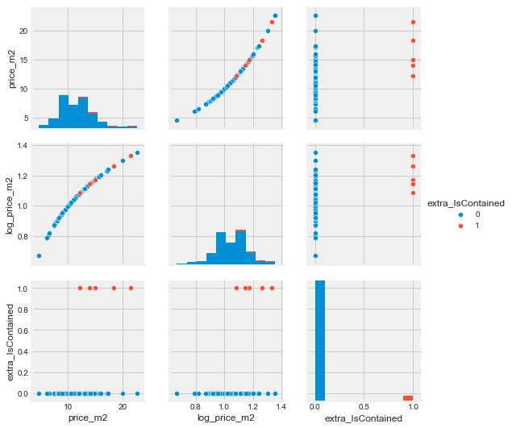

```python
sns.pairplot(train_sample[[TARGET,LOG_TARGET,'extra_IsContained']], hue="extra_IsContained")
```

Can you notice that, overall, when 'extra_IsContained' = 1 (meaning that the discriminative word 'extra' is present in the description) the TARGET has higher values?! What about some other discriminative words we previously found with the chi-squared test?

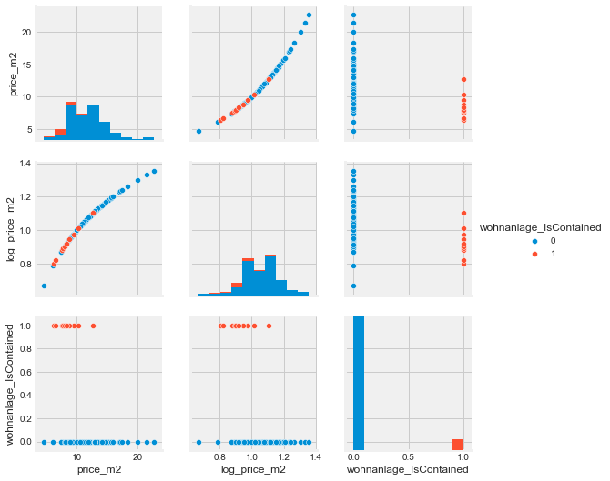

```python
sns.pairplot(train_sample[[TARGET,LOG_TARGET,'wohnanlage_IsContained']], hue="wohnanlage_IsContained")
```

Can you notice that, overall, when 'wohnanlage_IsContained' = 1 (meaning that the discriminative word 'wohnanlage' that means 'residential complex' is present in the description) the TARGET has lower values?!  
Without checking the other discriminative words, the two example above show that the procedure we performed on the description allows to extract relevant binary features that are good indicators of more expensive apartments (in the case of the word 'extra') or cheaper apartments (in the case of the word 'wohnanlage').

##### Let's check now how the TARGET behaves with respect to spatial (latitude, longitude,...) information:

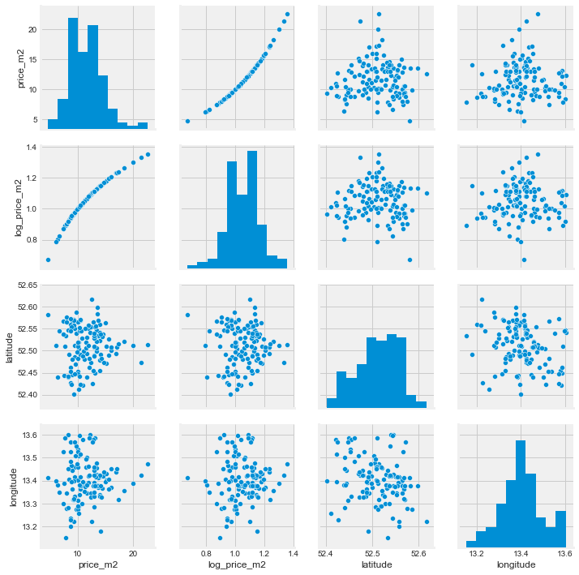

```python
sns.pairplot(train_sample[[TARGET,LOG_TARGET,'latitude','longitude']])
```

```python
#create new variable 'radius' from 'latitude' and 'longitude'
var = 'radius'
train[var] = train.apply(lambda x : (np.square(x['latitude']-train['latitude'].mean()) + np.square(x['longitude']-train['longitude'].mean()) ),axis=1)
```

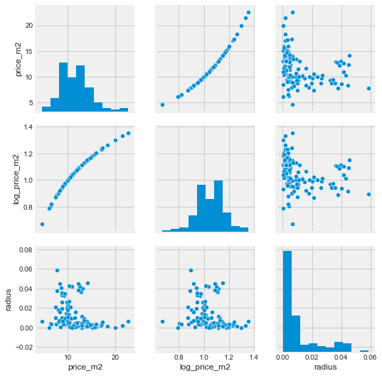

```python
train_sample = train.sample(frac=0.005, random_state=1234).reset_index(drop=True)
sns.pairplot(train_sample[[TARGET,LOG_TARGET,'radius']])
```

Can you notice that the TARGET has an exponential relationship with respect to 'radius' (TARGET = exp(-a*radius))?  
Let's create anathore variable 'radius_exp' applying exp function to 'radius':

```python
var = 'radius_exp'
train[var] = train.apply(lambda x : np.exp(-1*(x['radius'] - train['radius'].mean())/train['radius'].std()) ,axis=1)
```

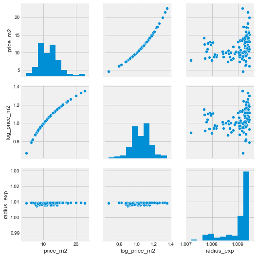

```python
train_sample = train.sample(frac=0.005, random_state=1234).reset_index(drop=True)
sns.pairplot(train_sample[[TARGET,LOG_TARGET,'radius_exp']])
```

##### What about 'zip_code', 'district_id', 'zone_id' and 'street'?

```python
train['zip_code'].describe(include='all')
```

```
count    25190.000000
mean     12019.677293
std       1308.663639
min      10115.000000
25%      10589.000000
50%      12247.000000
75%      13187.000000
max      14199.000000
Name: zip_code, dtype: float64
```

```python
train['district_id'].describe(include='all')
```

```
count              25190
unique                12
top       11000000_4_006
freq                3484
Name: district_id, dtype: object
```

```python
train['zone_id'].describe(include='all')
```

```
count              25190
unique                94
top       11000000_5_009
freq                1475
Name: zone_id, dtype: object
```

```python
train['street'].describe(include='all')
```

```
count              25190
unique              5842
top       Chausseestraße
freq                4873
Name: street, dtype: object
```

**Note:** 'zip_code' has a huge number of distinct values and has to be treated as a categorical variable. Therefore it is not suitable for the training of the algorithms because we should apply One Hot Encoding and produce as many binary features as the number of unique zip codes. We could also try to use a chi-squared test in order to find the most relevant zip codes but it would be not so effective with so many distinct value.  
Considering the fact that we are already taking into account spatial information thanks to 'latidude', 'longitude', 'radius', etc. we could ignore the 'zip_code' variable and drop it.

Same considerations can be done for the variables 'distict_id' and 'zone_id' that identify a sub_area inside the zip_code.  
Moreover, if we eliminate 'zip_code' these variables loose meaning (2 apartments with same 'district_id' can be in different areas with different 'zip_code'). Therefore we drop also these 2 variables.  
Same problem arises also with the categorical variable 'street' to which applying a chi-squared test in order to find the most discriminative Streets would be possible but expensive (too many distinct values of 'street'). Therefore we choose to drop also the variable 'street' for now.

```python
#drop 'zip_code', 'district_id', 'zone_id', 'street'
print(train.shape)
train = train.drop(['zip_code', 'district_id', 'zone_id', 'street'], axis = 1)
print(train.shape)
```

```
(25190, 45)
(25190, 41)
```

##### What about the variable 'floor'?

```python
train['floor'].describe(include = 'all')
```

```
count    25190.000000
mean         2.392457
std          1.564856
min         -1.000000
25%          1.000000
50%          2.000000
75%          3.000000
max          6.000000
Name: floor, dtype: float64
```

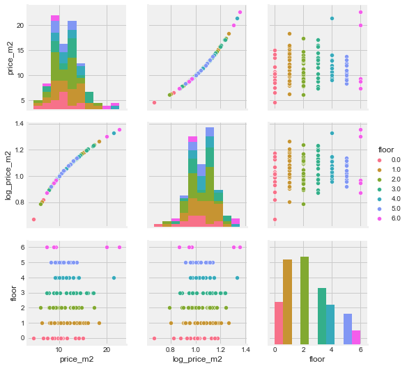

```python
sns.pairplot(train_sample[[TARGET,LOG_TARGET,'floor']], hue="floor")
```

```python
var = 'floor_below_4'
train[var] = train.apply(lambda x : 1 if (x['floor'] <4 )    else 0 ,axis=1)
```

```python
#drop 'floor'
train = train.drop('floor', axis = 1)
```

```python
#we drop also the text variable 'description' from which we already extracted relevant information
train = train.drop('description', axis = 1)
```

### 1.6 Correlation Analysis

Let's perform correlation analysis in order to spot redundant features or features that are not correlated with the target:

We avoid to check all the numerical features at once, otherwise it would be complicated to visualize it.

```python
FEATURE_LIST = [TARGET, LOG_TARGET, 'area', 'living_space', 'num_rooms', 'num_bathrooms', 'num_bedrooms', 'num_floors']
```

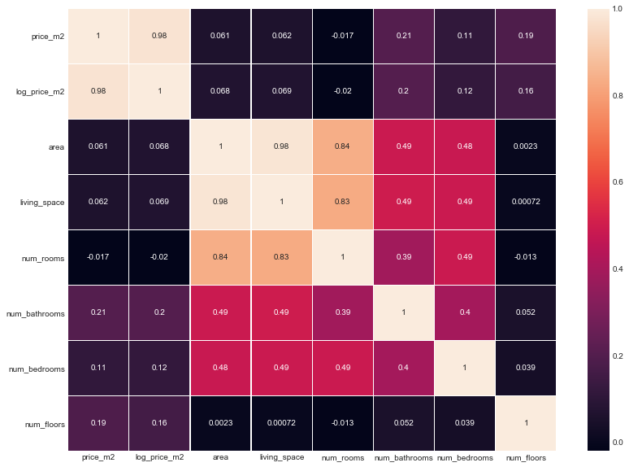

```python
fig, ax = plt.subplots(figsize=(12,10))         # Sample figsize in inches
#sns.heatmap(df1.iloc[:, 1:6:], annot=True, linewidths=.5, ax=ax)
sns.heatmap(train[FEATURE_LIST].corr(), annot=True, linewidths=.3)
```

- 'area' and 'living_space' both show small correlation with the TARGET and they have high correlation between them -> we should consider to eliminate at least one of them;
- 'area' and 'living_space' are strongly correlated with 'number_rooms' and 'number_rooms' is pretty correlated with 'num_bathrooms' and 'num_bedrooms'. Finally 'number_rooms' has no correlation with TARGET --> we should consider to eliminate 'number_rooms';

##### Let's keep track of the features we should remove:

```python
SHOULD_REMOVE = ['area','number_rooms']
```

```python
FEATURE_LIST = [TARGET, LOG_TARGET, 'latitude', 'longitude', 'radius', 'radius_exp']
```

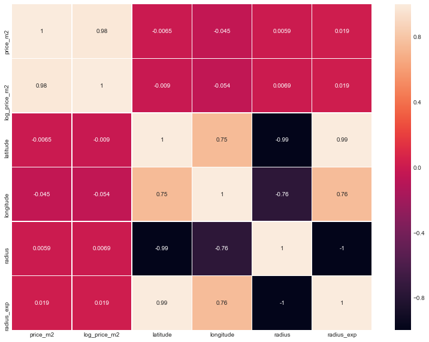

```python
fig, ax = plt.subplots(figsize=(12,10))         # Sample figsize in inches
#sns.heatmap(df1.iloc[:, 1:6:], annot=True, linewidths=.5, ax=ax)
sns.heatmap(train[FEATURE_LIST].corr(), annot=True, linewidths=.3)
```

- 'latitude', 'longitude', 'radius' and 'radius_exp' are all strongly correlated between them. Among them, 'latitude' and 'radius' are the least correlated with TARGET. Moreover 'latitude' and 'radius' are almost perfectly correlated with 'radius_exp' (-0.99 means almost perfect negative correlation and 0.00 means almost perfect positive correlation). --> We should consider to remove 'latitude' and 'radius'.

```python
SHOULD_REMOVE.extend(['latitude', 'radius'])
```

```python
FEATURE_LIST = [TARGET, LOG_TARGET, 'building_year', 'building_year_^2', 'posted_at', 'num_days']
```

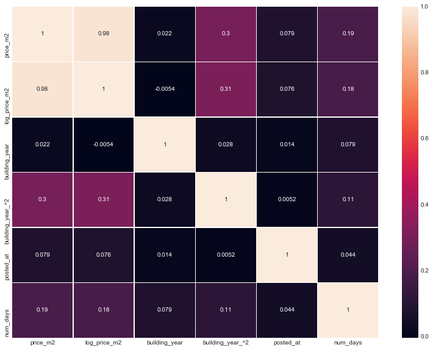

```python
fig, ax = plt.subplots(figsize=(12,10))         # Sample figsize in inches
#sns.heatmap(df1.iloc[:, 1:6:], annot=True, linewidths=.5, ax=ax)
sns.heatmap(train[FEATURE_LIST].corr(), annot=True, linewidths=.3)
```

Notice how 'building_year^2' is much more correlated with TARGET if compared to 'building_year'.  
For now we keep both 'building_year' and 'building_year^2'.

- 'posted_at' shows small correlation with TARGET. Moreover, when we plotted in the scatter plot above 'TARGET' and 'posted_at', we did not find any particoular relation. -> We should consider to remove 'posted_at'.

```python
SHOULD_REMOVE.append('posted_at')
```

### 1.7 OHE of the CATEGORICAL variables

Ok, we are done with the correlation analysis. The other variables we have are CATEGORICAL or BINARY, therefore correlation analysis is not suitable for that.  
Let's check the CATEGORICAL variables we still have ('apartment_type', 'condition', 'interior_quality'):

##### 'apartment_type'

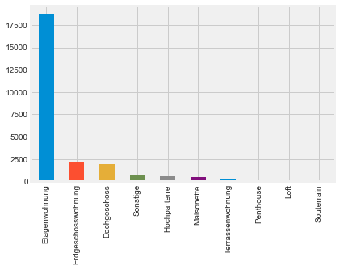

```python
train['apartment_type'].value_counts().plot(kind='bar', stacked = True)
```

```python
train['apartment_type'].value_counts()
```

```
Etagenwohnung         18752
Erdgeschosswohnung     2114
Dachgeschoss           1945
Sonstige                770
Hochparterre            591
Maisonette              480
Terrassenwohnung        251
Penthouse               149
Loft                     84
Souterrain               54
Name: apartment_type, dtype: int64
```

##### English translation:

- Apartment
- Ground floor apartment
- Attic
- Other
- Raised ground floor
- Maisonette
- Terrace apartment
- Penthouse
- Loft
- Basement

There are 10 distinct apartment_type --> at leat 9 distinct binary features (too much): Let's select the best 3 binary_features.

```python
apartment_type_OHE = pd.get_dummies(train['apartment_type'],prefix='is', drop_first=False)
```

```python
apartment_types = list(apartment_type_OHE.columns)
print(apartment_types)
```

```
['is_Dachgeschoss', 'is_Erdgeschosswohnung', 'is_Etagenwohnung', 'is_Hochparterre', 'is_Loft', 'is_Maisonette', 'is_Penthouse', 'is_Sonstige', 'is_Souterrain', 'is_Terrassenwohnung']
```

```python
#we now retrieve the most important binary variables with respect to the variable 'above_average'
print("Extracting best binary variables by a chi-squared test")
t0 = time()
ch2 = SelectKBest(chi2, k=3) #default K = 10
description_train = ch2.fit_transform(apartment_type_OHE,train['above_average'])
if apartment_types:
    # keep selected feature names
    vars_to_keep = [apartment_types[i] for i in ch2.get_support(indices=True)]
print("done in %fs" % (time() - t0))
print()
print("Most discriminative binary features:")
print(vars_to_keep)
```

```
Extracting best binary variables by a chi-squared test
done in 0.006981s

Most discriminative binary features:
['is_Dachgeschoss', 'is_Erdgeschosswohnung', 'is_Penthouse']
```

```python
#add them to the training
print(train.shape)
# use pd.concat to join the new columns with your original dataframe
train = pd.concat([train,apartment_type_OHE[vars_to_keep]],axis=1)

# now drop the original  column (we don't need it anymore)
train = train.drop(['apartment_type'],axis=1)
print(train.shape)
```

```
(25190, 40)
(25190, 42)
```

##### 'condition'

```python
train['condition'].value_counts()
```

```
Modernisiert                8009
Gepflegt                    5807
Erstbezug nach Sanierung    2583
Vollständig renoviert       2512
Saniert                     2216
Neuwertig                   2168
Erstbezug                   1603
Renovierungsbedürftig        161
Nach Vereinbarung            130
Abbruchreif                    1
Name: condition, dtype: int64
```

Also 'condition' has 10 different values: let's apply the same procedure.

```python
condition_OHE = pd.get_dummies(train['condition'],prefix='is', drop_first=False)
```

```python
condition_types = list(condition_OHE.columns)
print(condition_types)
```

```
['is_Abbruchreif', 'is_Erstbezug', 'is_Erstbezug nach Sanierung', 'is_Gepflegt', 'is_Modernisiert', 'is_Nach Vereinbarung', 'is_Neuwertig', 'is_Renovierungsbedürftig', 'is_Saniert', 'is_Vollständig renoviert']
```

```python
#we now retrieve the most important binary variables with respect to the variable 'above_average'
print("Extracting best binary variables by a chi-squared test")
t0 = time()
ch2 = SelectKBest(chi2, k=3) #default K = 10
description_train = ch2.fit_transform(condition_OHE,train['above_average'])
if True:
    # keep selected feature names
    vars_to_keep = [condition_types[i] for i in ch2.get_support(indices=True)]
print("done in %fs" % (time() - t0))
print()
print("Most discriminative binary features:")
print(vars_to_keep)
```

```
Extracting best binary variables by a chi-squared test
done in 0.009972s

Most discriminative binary features:
['is_Erstbezug', 'is_Gepflegt', 'is_Neuwertig']
```

```python
#add them to the training
print(train.shape)
# use pd.concat to join the new columns with your original dataframe
train = pd.concat([train,condition_OHE[vars_to_keep]],axis=1)

# now drop the original  column (we don't need it anymore)
train = train.drop(['condition'],axis=1)
print(train.shape)
```

```
(25190, 42)
(25190, 44)
```

##### 'interior_quality'

```python
#'interior_quality'
train['interior_quality'].value_counts()
```

```
Normale Qualität     13778
Gehobene Qualität    10469
Luxus                  777
Einfache Qualität      166
Name: interior_quality, dtype: int64
```

'interior_quality' has 4 different values -> 3 different binary variables:

```python
interior_quality_OHE = pd.get_dummies(train['interior_quality'],prefix='is', drop_first=True)
```

```python
#add them to the training
print(train.shape)
# use pd.concat to join the new columns with your original dataframe
train = pd.concat([train,interior_quality_OHE],axis=1)

# now drop the original  column (we don't need it anymore)
train = train.drop(['interior_quality'],axis=1)
print(train.shape)
```

```
(25190, 44)
(25190, 46)
```

Ok, let's check which features we have now:

```python
FEATURES = list(train.columns)
#id and 'above_average' will not be used  as features
FEATURES.remove('id')
FEATURES.remove('above_average')

print("NUMBER OF FEATURES: " + str(len(FEATURES)))
print()
print(FEATURES)
print()
print("NUMBER OF FEATURES TO EVENTUALLY ELIMINATE: " + str(len(SHOULD_REMOVE)))
print()
print(SHOULD_REMOVE)
```

[output not shown]

##### How many binary features we have?

```python
BINARY_FEATURES = ['floor_imputed', 'num_rooms_imputed', 'living_space_imputed',
                   'num_bedrooms_imputed', 'num_bathrooms_imputed', 'num_floors_imputed',
                   'apartment_type_imputed', 'condition_imputed', 'interior_quality_imputed',
                   'description_missing', 'kabelanschluss_IsContained', 'extra_IsContained',
                   'sprechanlag_IsContained', 'hausmeister_IsContained', 'treppenhausreinigun_IsContained',
                   'winterdienst_IsContained', 'wohnanlage_IsContained', 'wärmedämmung_IsContained',
                    'is_Dachgeschoss', 'is_Erdgeschosswohnung', 'is_Penthouse', 'is_Erstbezug', 'is_Gepflegt',
                   'is_Neuwertig', 'is_Gehobene Qualität', 'is_Luxus', 'is_Normale Qualität']
print("Number of binary features: " + str(len(BINARY_FEATURES)))
```

```
Number of binary features: 27
```

##### Which are the 15 most important ones?

```python
#we now retrieve the most important binary variables with respect to the variable 'above_average'
print("Extracting best binary variables by a chi-squared test")
t0 = time()
ch2 = SelectKBest(chi2, k=15) #default K = 10
description_train = ch2.fit_transform(train[BINARY_FEATURES],train['above_average'])
if True:
    # keep selected feature names
    binary_vars_to_keep = [BINARY_FEATURES[i] for i in ch2.get_support(indices=True)]
print("done in %fs" % (time() - t0))
print()
print("Most discriminative binary features:")
print(binary_vars_to_keep)
```

[output not shown]

## Recap:

- we created a new variable 'building_year^2' because we noticed a parabolic relationship between TARGET and 'building_year';
- we dropped 'endet_at' because was strongly correlated with 'posted_at' and 'num_days';
- we dropped some binary imputation features using a chi-squared test;
- we created variables 'radius' and 'radius_exp'
- we dropped 'zip_code', 'district_id', 'zone_id', 'street' because not usefull in the context;
- we created the binary variable 'floor_below_4' and dropped 'floor';
- we add in the SHOULD_REMOVE list some numerical variables after performing correlation analysis;
- we applied OHE to the categorical variables 'apartment_type', 'condition' and 'interior_quality' keeping only the 3 best binary features of each variable;

Let's apply the same procedure to the test:

```python
#create new variable 'building_year_^2'
var = 'building_year_^2'
test[var] = test.apply(lambda x : np.square(x['building_year']-train['building_year'].mean()),axis=1)
```

```python
test = test.drop('ended_at', axis = 1)
```

```python
binary_imputetation_features = ['area_imputed',
       'building_year_imputed', 'num_days_imputed', 'floor_imputed',
       'num_rooms_imputed', 'living_space_imputed', 'num_bedrooms_imputed',
       'num_bathrooms_imputed', 'num_floors_imputed', 'latitude_imputed',
       'longitude_imputed', 'apartment_type_imputed', 'condition_imputed',
       'interior_quality_imputed', 'district_id_imputed', 'zone_id_imputed',
       'street_imputed', 'description_missing']
```

```python
binary_vars_to_keep = ['floor_imputed', 'num_rooms_imputed', 'living_space_imputed',
                       'num_bedrooms_imputed', 'num_bathrooms_imputed',
                       'num_floors_imputed', 'apartment_type_imputed',
                       'condition_imputed', 'interior_quality_imputed', 'description_missing']
```

```python
test.columns
```

```
Index(['id', 'price_m2', 'area', 'building_year', 'posted_at', 'num_days',
       'zip_code', 'district_id', 'zone_id', 'street', 'latitude', 'longitude',
       'floor', 'num_rooms', 'living_space', 'num_bedrooms', 'num_bathrooms',
       'num_floors', 'apartment_type', 'condition', 'interior_quality',
       'description', 'log_price_m2', 'area_imputed', 'building_year_imputed',
       'num_days_imputed', 'floor_imputed', 'num_rooms_imputed',
       'living_space_imputed', 'num_bedrooms_imputed', 'num_bathrooms_imputed',
       'num_floors_imputed', 'latitude_imputed', 'longitude_imputed',
       'apartment_type_imputed', 'condition_imputed',
       'interior_quality_imputed', 'district_id_imputed', 'zone_id_imputed',
       'street_imputed', 'description_missing', 'kabelanschluss_IsContained',
       'extra_IsContained', 'sprechanlag_IsContained',
       'hausmeister_IsContained', 'treppenhausreinigun_IsContained',
       'winterdienst_IsContained', 'wohnanlage_IsContained',
       'wärmedämmung_IsContained', 'building_year_^2'],
      dtype='object')
```

```python
#Let's drop the other features
feature_to_eliminate = []
for feature in binary_imputetation_features:
    if feature in binary_vars_to_keep:
        continue
    else:
        feature_to_eliminate.append(feature)
print(test.shape)
test = test.drop(feature_to_eliminate, 1)
print(test.shape)
```

```
(10796, 50)
(10796, 42)
```

```python
#create new variable 'radius' from 'latitude' and 'longitude'
var = 'radius'
test[var] = test.apply(lambda x : (np.square(x['latitude']-train['latitude'].mean()) + np.square(x['longitude']-train['longitude'].mean()) ),axis=1)
```

```python
var = 'radius_exp'
test[var] = test.apply(lambda x : np.exp(-1*(x['radius'] - train['radius'].mean())/train['radius'].std()) ,axis=1)
```

```python
#drop 'zip_code', 'district_id', 'zone_id', 'street'
print(test.shape)
test = test.drop(['zip_code', 'district_id', 'zone_id', 'street'], axis = 1)
print(test.shape)
```

```
(10796, 44)
(10796, 40)
```

```python
var = 'floor_below_4'
test[var] = test.apply(lambda x : 1 if (x['floor'] <4 )    else 0 ,axis=1)
```

```python
#drop 'floor'
test = test.drop('floor', axis = 1)
```

```python
#we drop also the text variable 'description' from which we already extracted relevant information
test = test.drop('description', axis = 1)
```

```python
apartment_type_OHE = pd.get_dummies(test['apartment_type'],prefix='is', drop_first=False)
```

```python
vars_to_keep = ['is_Dachgeschoss', 'is_Erdgeschosswohnung', 'is_Penthouse']
```

```python
#add them to the test
print(test.shape)
# use pd.concat to join the new columns with your original dataframe
test = pd.concat([test,apartment_type_OHE[vars_to_keep]],axis=1)

# now drop the original  column (we don't need it anymore)
test = test.drop(['apartment_type'],axis=1)
print(test.shape)
```

```
(10796, 39)
(10796, 41)
```

```python
condition_OHE = pd.get_dummies(test['condition'],prefix='is', drop_first=False)
```

```python
vars_to_keep = ['is_Erstbezug', 'is_Gepflegt', 'is_Neuwertig']
```

```python
#add them to the test
print(test.shape)
# use pd.concat to join the new columns with your original dataframe
test = pd.concat([test,condition_OHE[vars_to_keep]],axis=1)

# now drop the original  column (we don't need it anymore)
test = test.drop(['condition'],axis=1)
print(test.shape)
```

```
(10796, 41)
(10796, 43)
```

```python
interior_quality_OHE = pd.get_dummies(test['interior_quality'],prefix='is', drop_first=True)
```

```python
#add them to the test
print(test.shape)
# use pd.concat to join the new columns with your original dataframe
test = pd.concat([test,interior_quality_OHE],axis=1)

# now drop the original  column (we don't need it anymore)
test = test.drop(['interior_quality'],axis=1)
print(test.shape)
```

```
(10796, 43)
(10796, 45)
```

Ok, we are ready to train and test some Regression Model.

# 2 Regression Model

### 2.1 Introduction

In this section we will try some of the regression algorithms from sklear.  
In order to not make the notebook too long and save time, we will try just few of the available algorithms.  
In particoular we will play with the following models:

Each algorithm is further discussed later. When possible, we will perform hyper parameter tuning.

We will evaluate the different models with 10 fold crossvalidation keeping into account the following metrics:

- Means Squared Error (MSE);
- r2 that describe how good the algorithms perform with respect to predicting the mean. (from sklearn documentation: R^2 (coefficient of determination) regression score function. Best possible score is 1.0 and it can be negative (because the model can be arbitrarily worse). A constant model that always predicts the expected value of y, disregarding the input features, would get a R^2 score of 0.0. )

We try to predict LOG_TARGET (normalized). In case we need later to come back to the original TARGET variable we can easily apply the inverse function.

Before trying the different models, we normalize the data. This is a common procedure that is usefull for some of the algorithms listed above (all except DT and RF) because they are sensible to scaling.  
We use the library function StandarScaler by Sklearn.

### 2.2 Normalization

```python
from sklearn.preprocessing import StandardScaler
#normalize train
scaler = StandardScaler()
scaler.fit(train[FEATURES])
train[FEATURES] = scaler.transform(train[FEATURES])
```

```python
#normalize test
test[FEATURES] = scaler.transform(test[FEATURES])
```

```python
train[LOG_TARGET].describe()
```

```
count    2.519000e+04
mean    -1.098257e-15
std      1.000020e+00
min     -5.282468e+00
25%     -6.774280e-01
50%     -4.237554e-02
75%      6.845409e-01
max      4.375358e+00
Name: log_price_m2, dtype: float64
```

```python
test[LOG_TARGET].describe()
```

```
count    10796.000000
mean        -0.006884
std          0.989210
min         -4.612862
25%         -0.671842
50%         -0.042376
75%          0.651668
max          4.615262
Name: log_price_m2, dtype: float64
```

```python
#remove TARGET and LOG target from the feature list
FEATURES.remove(TARGET)
FEATURES.remove(LOG_TARGET)
```

### 2.3 Crossvalidation

```python
#import libraries
from sklearn.model_selection import cross_validate
import sklearn.metrics as m
from sklearn.metrics import  make_scorer

#define score metrics
r2_scorer = make_scorer(m.r2_score)
mean_squared_error_scorer = make_scorer(m.mean_squared_error)

scoring = {'r2': r2_scorer, 'mean_squared_error': mean_squared_error_scorer}
```

Let's define a function to perform our procedure:

```python
#define function
def crossValidate(reg, verbose = True, scoring = scoring, FEATURES = FEATURES):
    #compute scores with 10 fold CrossValidation
    scores = cross_validate(reg, train[FEATURES], train[LOG_TARGET], scoring=scoring,cv=10, return_estimator=True)

    #retrieve test metrics
    test_MSE = scores['test_mean_squared_error'].mean()
    test_r2 = scores['test_r2'].mean()

    #compute also training metrics
    reg.fit(train[FEATURES], train[LOG_TARGET])
    train_predictions = reg.predict(train[FEATURES])
    train_r2 = m.r2_score(train[LOG_TARGET], train_predictions)
    train_mean_squared_error = m.mean_squared_error(train[LOG_TARGET], train_predictions)
    #print(scores.keys())
    if verbose:
        print(reg)
        print()

        #scores
        print("training time: " + str(round(scores['fit_time'].mean(),2)))
        print("prediction time: " + str(round(scores['score_time'].mean(),2)))
        print()

        print("train_mean_squared_error : " + str(round(train_mean_squared_error,5)))
        print("average test mean_squared_error : " + str(round(test_MSE,5)))
        print()

        print("train_r2_score : " + str(round(train_r2,3)))
        print("average test_r2: " + str(round(test_r2,3)))
    return {'predictor': reg, 'train_MSE' : train_mean_squared_error, 'train_r2': train_r2, 'test_MSE': test_MSE, 'test_r2': test_r2 }
```

### Linear Regression

```python
from sklearn import linear_model
reg = linear_model.LinearRegression()
result = crossValidate(reg)
```

```
LinearRegression(copy_X=True, fit_intercept=True, n_jobs=None, normalize=False)

training time: 0.04
prediction time: 0.0

train_mean_squared_error : 0.51636
average test mean_squared_error : 410482521072.9072

train_r2_score : 0.484
average test_r2: -399863835170.279
```

We can notice that the Linear Regression Model is not able to learn and it drastically overfitts. This is probabli due to the fact that we have too many features (a lot of them are also binary features). Therefore, if we want to have a better model we should try to perform a better feature selection (we will discuss it later).  
Let's check now how Lasso regression performs.  
The cool thing about Lasso regression is that it intrinsically performs feature selection, setting to zero most of the features' coefficients.

### Lasso Regression

```python
train_MSE = []
test_MSE = []
train_r2 = []
test_r2 = []
alpha_values = [0.01,0.025, 0.05, 0.1, 0.2, 0.3, 0.4, 0.5, 0.75, 1]
```

```python
for a in alpha_values:
    reg = linear_model.Lasso(alpha=a)
    result = crossValidate(reg, False)
    train_MSE.append(result['train_MSE'])
    test_MSE.append(result['test_MSE'])
    train_r2.append(result['train_r2'])
    test_r2.append(result['test_r2'])
```

#### Plot train and test MSE with respect to alpha:

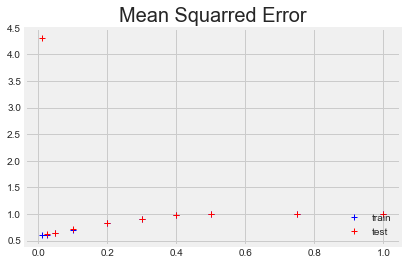

```python
plt.plot(alpha_values, train_MSE,'b+')
plt.plot(alpha_values, test_MSE,'r+' )
plt.legend(['train', 'test'], loc='lower right')
plt.title('Mean Squarred Error', fontsize=20)
plt.show()
```

How can we notice, Lasso Regression works much better than simple Linear Regression because it is able to perform feature selection. From the plot above seems that the lowest MSE is obtained for small values of alpha (small l1 penalization).

#### Plot train and test r2_score with respect to alpha:

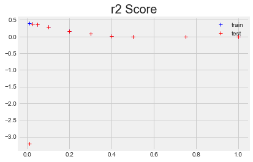

```python
plt.plot(alpha_values, train_r2,'b+')
plt.plot(alpha_values, test_r2,'r+' )
plt.title('r2 Score', fontsize=20)
plt.legend(['train', 'test'], loc='upper right')
plt.show()
```

Also from this plot we can deduce that the best performance (highest r2 score) for Lasso are obtained with small values of alpha (alpha = 0.025).

#### Analyze regression model for best alpha:

```python
best_alpha = 0.025
reg = linear_model.Lasso(alpha=best_alpha)
result = crossValidate(reg, True)
```

```
Lasso(alpha=0.025, copy_X=True, fit_intercept=True, max_iter=1000,
      normalize=False, positive=False, precompute=False, random_state=None,
      selection='cyclic', tol=0.0001, warm_start=False)

training time: 0.1
prediction time: 0.0

train_mean_squared_error : 0.61539
average test mean_squared_error : 0.61927

train_r2_score : 0.385
average test_r2: 0.381
```

```python
#keep track of the performance for the different algorithms (only the ones performing decently)
algoirthms_name = []
best_hyperparameter = []
train_MSE_results = []
test_MSE_results = []
train_r2_results = []
test_r2_results = []
```

```python
#keep track of the performance
algoirthms_name.append("Lasso")
best_hyperparameter.append("alpha = 0.025")
train_MSE_results.append(result['train_MSE'])
test_MSE_results.append(result['test_MSE'])
train_r2_results.append(result['train_r2'])
test_r2_results.append(result['test_r2'])
```

#### Check feature importance:

It is intersting to check which feature coefficients have been set to zero.

```python
features_ordered_by_importance = []
importances = result['predictor'].coef_

indices = np.argsort(importances)[::-1]
values_ordered_by_importance = []


for f in range(len(FEATURES)):
    #print("%d.  %s (%f)" % (f + 1, name_mapping_dictionary[FEATURES[indices[f]]], importances[indices[f]]))
    features_ordered_by_importance.append(FEATURES[indices[f]])
    values_ordered_by_importance.append(importances[indices[f]])
```

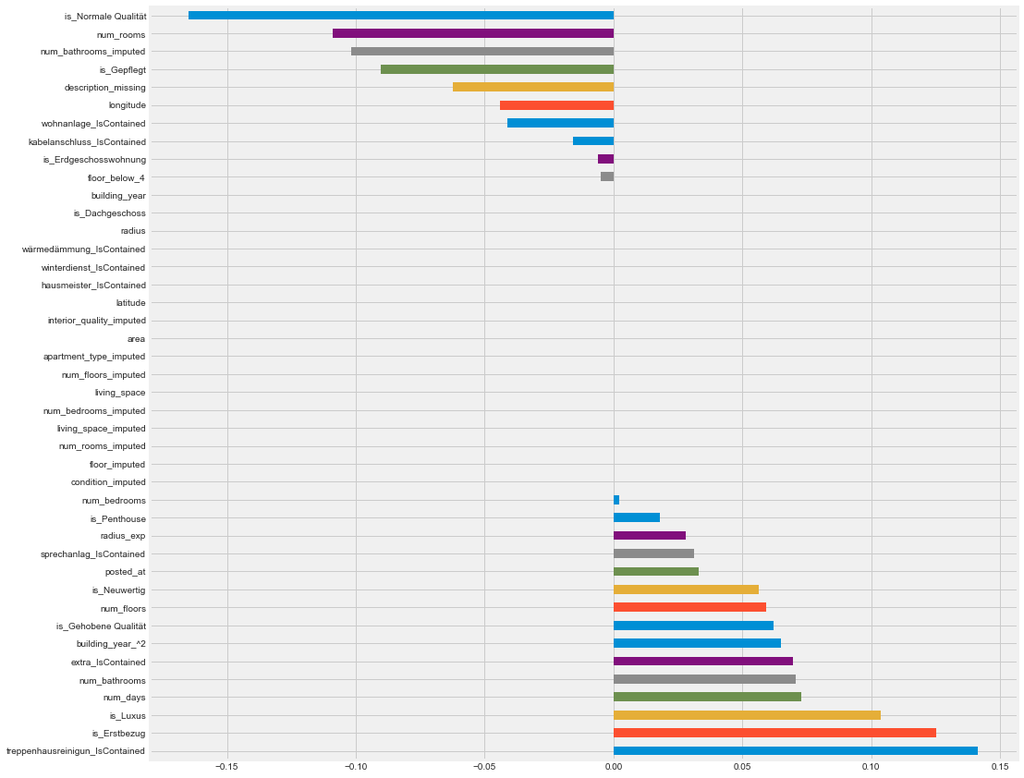

```python
(pd.Series(values_ordered_by_importance, index=features_ordered_by_importance)
   .plot(kind='barh', figsize = (15,15)))
```

Notice how many coefficients have been set to zero.

### Ridge regression

Ridge Regression uses l2 penalization. Differently from l1 penalization, l2 does not set coefficients to zero (so it does not performs feature selection) but tends to shrink all the coefficients to zero as the importance of the penalization term increases.

```python
train_MSE = []
test_MSE = []
train_r2 = []
test_r2 = []
alpha_values = [0.01,0.025, 0.05, 0.1, 0.2, 0.3, 0.4, 0.5, 0.75, 1]
```

```python
for a in alpha_values:
    reg = linear_model.Ridge(alpha=a)
    result = crossValidate(reg, False)
    train_MSE.append(result['train_MSE'])
    test_MSE.append(result['test_MSE'])
    train_r2.append(result['train_r2'])
    test_r2.append(result['test_r2'])
```

#### Plot train and test MSE with respect to alpha:

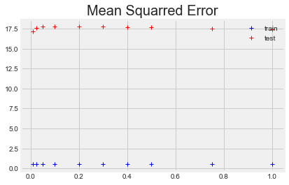

```python
plt.plot(alpha_values, train_MSE,'b+')
plt.plot(alpha_values, test_MSE,'r+' )
plt.legend(['train', 'test'], loc='upper right')
plt.title('Mean Squarred Error', fontsize=20)
plt.show()
```

#### Plot train and test r2_score with respect to alpha:

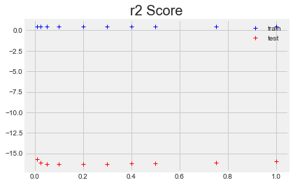

```python
plt.plot(alpha_values, train_r2,'b+')
plt.plot(alpha_values, test_r2,'r+' )
plt.title('r2 Score', fontsize=20)
plt.legend(['train', 'test'], loc='upper right')
plt.show()
```